# Nationwide Model

```python
import sys
!{sys.executable} -m pip install -U imbalanced-learn
!{sys.executable} -m pip install xgboost
```

```
     |████████████████████████████████| 1.7 MB 5.1 MB/s eta 0:00:01
```

```python
import pandas as pd
import numpy as np
import matplotlib.pyplot as plt
import seaborn as sns
import imblearn
import xgboost
```

```python
# allows us to see all features in dataset
pd.set_option('display.max_columns', None)
pd.set_option('display.max_rows', None)
```

```python
data = pd.read_csv('Data/TRAIN_SET_2022.csv')
```

```python
# check to see that data is properly loaded
data.head()
```

|  | RESTAURANT_SERIAL_NUMBER | RESTAURANT_PERMIT_NUMBER | RESTAURANT_NAME | RESTAURANT_LOCATION | RESTAURANT_CATEGORY | ADDRESS | CITY | STATE | ZIP | CURRENT_DEMERITS | CURRENT_GRADE | EMPLOYEE_COUNT | MEDIAN_EMPLOYEE_AGE | MEDIAN_EMPLOYEE_TENURE | INSPECTION_TIME | INSPECTION_TYPE | INSPECTION_DEMERITS | VIOLATIONS_RAW | RECORD_UPDATED | LAT_LONG_RAW | FIRST_VIOLATION | SECOND_VIOLATION | THIRD_VIOLATION | FIRST_VIOLATION_TYPE | SECOND_VIOLATION_TYPE | THIRD_VIOLATION_TYPE | NUMBER_OF_VIOLATIONS | NEXT_INSPECTION_GRADE_C_OR_BELOW |
| --- | --- | --- | --- | --- | --- | --- | --- | --- | --- | --- | --- | --- | --- | --- | --- | --- | --- | --- | --- | --- | --- | --- | --- | --- | --- | --- | --- | --- |
| 0 | DA1117270 | PR0004527 | SANDS EXPO HALL B2 CONCESSION | SANDS EXPO & CONVENTION CENTER | Snack Bar | 201 E Sands Ave | Las Vegas | Nevada | 89169-2617 | 0.0 | A | 25.0 | 27.95998269 | 13.004886 | 11/5/2013 16:15 | Routine Inspection | 11 | 2,042,153,022,955 | 1/6/2015 16:34 | (36.1221442, 115.1652749) | 204.0 | 215.0 | 302.0 | Critical | Major | Imminent Health Hazard | 4 | 0 |
| 1 | DA1014948 | PR0024221 | THAI NOODLES CAFE - RESTAURANT | THAI NOODLES CAFE | Restaurant | 6710 W CHEYENNE Ave | Las Vegas | Nevada | 89108-4588 | 3.0 | A | 7.0 | 27.71936533 | 3.922086 | 9/21/2012 13:00 | Routine Inspection | 9 | 214,216,229,230,233 | 2/21/2013 22:26 | (36.218691, 115.242913) | 214.0 | 216.0 | 229.0 | Major | Major | Non-Major | 5 | 0 |
| 2 | DA0861994 | PR0019017 | SANTA FE SPORTS BOOK GRILL | Santa Fe Station Hotel & Casino | Restaurant | 4949 N Rancho Dr | Las Vegas | Nevada | 89130-3505 | 8.0 | A | 23.0 | 26.44263674 | 10.312777 | 9/16/2011 11:50 | Routine Inspection | 9 | 202,215,233 | 4/6/2015 9:00 | (36.2498922, 115.2441383) | 202.0 | 215.0 | 233.0 | Critical | Major | Non-Major | 3 | 1 |
| 3 | DA0896719 | PR0001343 | Bracken, Walter Elem School Kit | Bracken, Walter Elem School | Elementary School Kitchen | 1200 N 27Th St | Las Vegas | Nevada | 89101-1517 | 0.0 | A | 14.0 | 33.98829267 | 4.163975 | 11/22/2011 11:40 | Routine Inspection | 5 | 214,230,233 | 2/21/2013 22:26 | (36.183669, 115.112355) | 214.0 | 230.0 | 233.0 | Major | Non-Major | Non-Major | 3 | 0 |
| 4 | DA1031041 | PR0006084 | HARD ROCK JOINT EAST SVC BAR FL 1 | HARD ROCK HOTEL & CASINO | Bar / Tavern | 4455 S Paradise Rd | Las Vegas | Nevada | 89169-6574 | 0.0 | A | 10.0 | 21.98028217 | 13.462786 | 11/9/2012 20:30 | Routine Inspection | 5 | 214,230,233 | 2/21/2013 22:26 | (36.1100828, 115.1538714) | 214.0 | 230.0 | 233.0 | Major | Non-Major | Non-Major | NaN | 0 |

```python
# check to see how many instances and features there are
data.shape
```

```
(15673, 28)
```

```python
# we can see that certain features have null values, where Non-Null counts are less than 15673
data.info()
```

```
<class 'pandas.core.frame.DataFrame'>
RangeIndex: 15673 entries, 0 to 15672
Data columns (total 28 columns):
 #   Column                            Non-Null Count  Dtype
---  ------                            --------------  -----
 0   RESTAURANT_SERIAL_NUMBER          15673 non-null  object
 1   RESTAURANT_PERMIT_NUMBER          15673 non-null  object
 2   RESTAURANT_NAME                   15608 non-null  object
 3   RESTAURANT_LOCATION               15473 non-null  object
 4   RESTAURANT_CATEGORY               15543 non-null  object
 5   ADDRESS                           15603 non-null  object
 6   CITY                              15437 non-null  object
 7   STATE                             15464 non-null  object
 8   ZIP                               15614 non-null  object
 9   CURRENT_DEMERITS                  15457 non-null  float64
```

[output cut: 20 more lines]

```python
# take a look at response variable counts - we should only 1 and 0
data['NEXT_INSPECTION_GRADE_C_OR_BELOW'].value_counts()
```

```
0       12947
1        2680
3           1
4           1
Goat        1
9           1
7           1
-3          1
Name: NEXT_INSPECTION_GRADE_C_OR_BELOW, dtype: int64
```

```python
# since we have some miscellaneous values for our response variable, we will drop these instances
data = data[(data['NEXT_INSPECTION_GRADE_C_OR_BELOW'] == '0') | (data['NEXT_INSPECTION_GRADE_C_OR_BELOW'] == '1')]
```

```python
# now let's split data into predictor and response variables
X, y = data.drop('NEXT_INSPECTION_GRADE_C_OR_BELOW', axis = 1).copy(), data['NEXT_INSPECTION_GRADE_C_OR_BELOW'].copy()
```

### Before we perform any pre-processing or exploration on our data, we will split our dataset into train-test sets to avoid data-leakage and to have a validation set

```python
from sklearn.model_selection import train_test_split

X_train, X_test, y_train, y_test = train_test_split(X, y, train_size = 0.8, random_state = 42)
```

```python
# we will use our training data to gain insights
explore = X_train.copy()
explore['NEXT_INSPECTION_GRADE_C_OR_BELOW'] = y_train.copy()
```

```python
explore.info()
```

```
<class 'pandas.core.frame.DataFrame'>
Int64Index: 12501 entries, 6593 to 7290
Data columns (total 28 columns):
 #   Column                            Non-Null Count  Dtype
---  ------                            --------------  -----
 0   RESTAURANT_SERIAL_NUMBER          12501 non-null  object
 1   RESTAURANT_PERMIT_NUMBER          12501 non-null  object
 2   RESTAURANT_NAME                   12449 non-null  object
 3   RESTAURANT_LOCATION               12342 non-null  object
 4   RESTAURANT_CATEGORY               12399 non-null  object
 5   ADDRESS                           12440 non-null  object
 6   CITY                              12309 non-null  object
 7   STATE                             12327 non-null  object
 8   ZIP                               12452 non-null  object
 9   CURRENT_DEMERITS                  12332 non-null  float64
```

[output cut: 20 more lines]

### We will first begin exploration of our categorical features, looking for things such as: variability within each feature (how many unique values each column takes) and redundancy (do two or more features measure/record the same thing?).

```python
# We will use 'RESTAURANT_SERIAL_NUMBER' as the identifier of a restaurant, thus we can drop 'RESTAURANT_NAME'
explore.drop('RESTAURANT_NAME', axis = 1, inplace = True)
```

```python
# we can see that our 'RESTAURANT_LOCATION' is highly variable. Additionally, it's possible we will encounter unseen
# locations in our test set, thus we will drop this feature as well
explore['RESTAURANT_LOCATION'].value_counts()
```

```
CAESARS PALACE HOTEL & CASINO                         89
MIRAGE HOTEL & CASINO                                 84
BELLAGIO HOTEL & CASINO                               81
MGM GRAND HOTEL & CASINO                              70
ARIA HOTEL & CASINO                                   69
Robertos Taco Shop                                    69
PARIS HOTEL & CASINO                                  66
FLAMINGO LV HOTEL & CASINO                            66
MANDALAY BAY HOTEL & CASINO                           65
COSMOPOLITAN RESORT & CASINO                          64
HARD ROCK HOTEL & CASINO                              64
HARRAHS LV HOTEL & CASINO                             64
Rio Suites Hotel                                      56
TREASURE ISLAND HOTEL & CASINO                        47
PLANET HOLLYWOOD RESORT AND CASINO                    43
BALLYS GRAND HOTEL                                    43
Golden Nugget Las Vegas                               42
PALAZZO HOTEL & CASINO                                42
WESTGATE HOTEL AND CASINO                             41
VENETIAN HOTEL & CASINO                               39
LUXOR HOTEL & CASINO                                  38
Pizza Hut                                             35
GREEN VALLEY RANCH                                    35
WYNN HOTEL & CASINO                                   33
South Point Hotel & Casino                            30
RIVIERA HOTEL & CASINO                                29
MONTE CARLO HOTEL & CASINO                            28
EXCALIBUR HOTEL & CASINO                              26
Texas Station Gambling Hall & Hotel                   25
Suncoast Hotel & Casino                               24
NEW YORK NEW YORK HOTEL & CASINO                      24
Dominos Pizza                                         24
TROPICANA LAS VEGAS HOTEL & CASINO                    24
Sunset Station Hotel & Casino                         23
Sams Town                                             22
McCarran Host International                           22
Subway                                                21
SILVER SEVENS HOTEL & CASINO                          21
Buffalo Wild Wings Grill & Bar                        21
KAIZEN FUSION ROLL & SUSHI                            20
```

[output cut: 4446 more lines]

```
Omelet House - Russell                                 1
DINOS                                                  1
P Ts Pub                                               1
CREPE STATION                                          1
Rebel Oil #37                                          1
Foothills Tavern                                       1
MARISCOS Y SUSHI SINALOA                               1
TheOffice Billiard Club                                1
JACK IN THE BOX #7239                                  1
FITPREP                                                1
Rebel #61                                              1
SIPS AND DIPS COFFEEHOUSE                              1
Bistro Pizza                                           1
TAKERO CACHONDO                                        1
Name: RESTAURANT_LOCATION, dtype: int64
```

```python
# drop 'RESTAURANT_LOCATION'
explore.drop('RESTAURANT_LOCATION', axis = 1, inplace = True)
```

```python
# Again, with 'RESTAURANT_PERMIT_NUMBER', we have many unique values and thus high variability. Similarly to
# 'RESTAURANT_LOCATION', it's possible we will encounter a new, unseen value in our test set. Thus, we will drop
# this feature as well.
explore['RESTAURANT_PERMIT_NUMBER'].value_counts()
```

```
PR0009870    10
PR0019729    10
PR0019924    10
PR0019641     9
PR0023840     9
PR0012160     8
PR0008421     8
PR0008094     8
PR0014943     8
PR0017360     8
PR0021181     8
PR0009338     8
PR0024086     8
PR0015006     7
PR0015005     7
PR0018400     7
PR0018495     7
PR0017991     7
PR0019730     7
PR0019869     7
PR0022483     7
PR0015707     7
PR0022524     7
PR0016714     7
PR0019441     7
PR0019925     7
PR0016101     7
PR0004693     7
PR0019189     6
PR0014232     6
PR0003002     6
PR0012113     6
PR0020728     6
PR0017217     6
PR0013865     6
PR0014672     6
PR0023296     6
PR0016186     6
PR0005912     6
PR0016385     6
```

[output cut: 7518 more lines]

```
PR0011680     1
PR0009132     1
PR0099462     1
PR0004992     1
PR0010214     1
PR0099547     1
PR0001939     1
PR0005081     1
PR0007754     1
PR0099609     1
PR0020274     1
PR0020059     1
PR0006453     1
PR0011552     1
Name: RESTAURANT_PERMIT_NUMBER, dtype: int64
```

```python
explore['RESTAURANT_CATEGORY'].value_counts()
```

```
Restaurant                     7418
Bar / Tavern                   1879
Snack Bar                      1028
Special Kitchen                 924
Buffet                          186
Portable Unit                   159
Pantry                          141
Meat/Poultry/Seafood            112
Food Trucks / Mobile Vendor      76
Caterer                          54
Kitchen Bakery                   50
Banquet Kitchen                  50
Garde Manger                     41
Bakery Sales                     37
Vegetable Prep                   36
Produce Market                   26
Concessions                      25
Institutional Food Service       25
Confection                       23
Elementary School Kitchen        15
Grocery Store Sampling           14
Banquet Support                  12
Barbeque                         12
Childcare Kitchens               12
Portable Bar                     11
Main Kitchen                      6
Gas Station                       6
Bark / Tavern                     5
Gastropub                         5
Jimmy Buffett                     4
Bar / TaVen                       3
Beer Bar                          2
Self-Service Food Truck           1
Farmers Market                    1
Name: RESTAURANT_CATEGORY, dtype: int64
```

```python
# drop 'RESTAURANT_PERMIT_NUMBER'
explore.drop('RESTAURANT_PERMIT_NUMBER', axis = 1, inplace = True)
```

```python
# check how many places score a c grade or below based on RESTAURANT_CATEGORY
explore.groupby(['RESTAURANT_CATEGORY', 'NEXT_INSPECTION_GRADE_C_OR_BELOW']).agg({'NEXT_INSPECTION_GRADE_C_OR_BELOW':'count'})
```

| RESTAURANT_CATEGORY | NEXT_INSPECTION_GRADE_C_OR_BELOW | NEXT_INSPECTION_GRADE_C_OR_BELOW |
| --- | --- | --- |
| Bakery Sales | 0 | 33 |
|  | 1 | 4 |
| Banquet Kitchen | 0 | 45 |
|  | 1 | 5 |
| Banquet Support | 0 | 7 |
|  | 1 | 5 |
| Bar / TaVen | 0 | 3 |
| Bar / Tavern | 0 | 1641 |
|  | 1 | 238 |
| Barbeque | 0 | 12 |
| Bark / Tavern | 0 | 4 |
|  | 1 | 1 |
| Beer Bar | 0 | 2 |
| Buffet | 0 | 157 |
|  | 1 | 29 |
| Caterer | 0 | 46 |
|  | 1 | 8 |
| Childcare Kitchens | 0 | 11 |
|  | 1 | 1 |
| Concessions | 0 | 23 |
|  | 1 | 2 |
| Confection | 0 | 20 |
|  | 1 | 3 |
| Elementary School Kitchen | 0 | 15 |
| Farmers Market | 0 | 1 |
| Food Trucks / Mobile Vendor | 0 | 62 |
|  | 1 | 14 |
| Garde Manger | 0 | 38 |
|  | 1 | 3 |
| Gas Station | 1 | 6 |
| Gastropub | 0 | 5 |
| Grocery Store Sampling | 0 | 13 |
|  | 1 | 1 |
| Institutional Food Service | 0 | 21 |
|  | 1 | 4 |
| Jimmy Buffett | 0 | 4 |
| Kitchen Bakery | 0 | 45 |
|  | 1 | 5 |
| Main Kitchen | 0 | 2 |
|  | 1 | 4 |
| Meat/Poultry/Seafood | 0 | 93 |
|  | 1 | 19 |
| Pantry | 0 | 111 |
|  | 1 | 30 |
| Portable Bar | 0 | 9 |
|  | 1 | 2 |
| Portable Unit | 0 | 124 |
|  | 1 | 35 |
| Produce Market | 0 | 22 |
|  | 1 | 4 |
| Restaurant | 0 | 6043 |
|  | 1 | 1375 |
| Self-Service Food Truck | 1 | 1 |
| Snack Bar | 0 | 876 |
|  | 1 | 152 |
| Special Kitchen | 0 | 788 |
|  | 1 | 136 |
| Vegetable Prep | 0 | 33 |
|  | 1 | 3 |

### Do certain restaurant types have higher percenatges of C grades or below? Let's find out!

```python
# First, let's drop restaurant types with low counts - this ensure that we don't get high percentages due to
# low counts. We will require a minimum count of 50
percent_experiment = explore.groupby("RESTAURANT_CATEGORY").filter(lambda x: len(x) >= 50)
```

```python
percent_experiment.head()
```

|  | RESTAURANT_SERIAL_NUMBER | RESTAURANT_CATEGORY | ADDRESS | CITY | STATE | ZIP | CURRENT_DEMERITS | CURRENT_GRADE | EMPLOYEE_COUNT | MEDIAN_EMPLOYEE_AGE | MEDIAN_EMPLOYEE_TENURE | INSPECTION_TIME | INSPECTION_TYPE | INSPECTION_DEMERITS | VIOLATIONS_RAW | RECORD_UPDATED | LAT_LONG_RAW | FIRST_VIOLATION | SECOND_VIOLATION | THIRD_VIOLATION | FIRST_VIOLATION_TYPE | SECOND_VIOLATION_TYPE | THIRD_VIOLATION_TYPE | NUMBER_OF_VIOLATIONS | NEXT_INSPECTION_GRADE_C_OR_BELOW |
| --- | --- | --- | --- | --- | --- | --- | --- | --- | --- | --- | --- | --- | --- | --- | --- | --- | --- | --- | --- | --- | --- | --- | --- | --- | --- |
| 6593 | DA0623951 | Restaurant | 3990 W RUSSELL | Las Vegas | Nevada | 89118 | 9.0 | A | 15.0 | 26.95973476 | 4.968052 | 3/12/2010 15:20 | Routine Inspection | 8 | 2,28,35 | 2/21/2013 22:26 | (36.08684, 115.192734) | 2.0 | 28.0 | 35.0 | Critical | Non-Major | Non-Major | 3 | 0 |
| 8116 | DA1066180 | Restaurant | 10890 S Eastern Ave | Henderson | Nevada | 89052-5707 | 5.0 | A | 13.0 | 21.48735408 | 5.031020 | 4/22/2013 13:40 | Routine Inspection | 19 | 20,620,921,121,329,300,000 | 4/25/2013 15:10 | (35.9950304, 115.0997945) | 206.0 | 209.0 | 211.0 | Critical | Critical | Major | 6 | 1 |
| 7732 | DA0988936 | Restaurant | 4350 E Sunset Rd 103 | Henderson | Nevada | 89014-2258 | 9.0 | A | 3.0 | 25.11499974 | 3.613487 | 6/8/2012 17:40 | Routine Inspection | 9 | 211,215,225,227,233 | 2/21/2013 22:26 | (36.0673083, 115.0083401) | 211.0 | 215.0 | 225.0 | Major | Major | Non-Major | 5 | 0 |
| 971 | DASTERMTP | Pantry | 221 N Rampart Blvd | Las Vegas | Nevada | 89145-5722 | 0.0 | A | 11.0 | 27.99717089 | 4.355604 | 11/7/2016 18:30 | Routine Inspection | 14 | 204,211,212,216,302 | 11/7/2016 19:33 | (36.175747, 115.2917528) | 204.0 | 211.0 | 212.0 | Critical | Major | Major | 5 | 0 |
| 13214 | DA0533209 | Restaurant | 4965 W Tropicana Ave 102 | Las Vegas | Nevada | 89103-7079 | 0.0 | A | 24.0 | 25.90664464 | 3.964433 | 7/20/2010 17:25 | Routine Inspection | 6 | 4,28,35 | 2/21/2013 22:26 | (36.1007082, 115.209325) | 4.0 | 28.0 | 35.0 | Major | Non-Major | Non-Major | 3 | 0 |

```python
# store all unique restaurant types in list
rest_type = list(percent_experiment['RESTAURANT_CATEGORY'].unique())
```

```python
# restaurant types with counts >= 50
rest_type
```

```
['Restaurant',
 'Pantry',
 'Bar / Tavern',
 'Special Kitchen',
 'Meat/Poultry/Seafood',
 'Snack Bar',
 'Portable Unit',
 'Food Trucks / Mobile Vendor',
 'Buffet',
 'Caterer',
 'Banquet Kitchen',
 'Kitchen Bakery']
```

```python
percents = []

for types in rest_type:
    # gets subset of explore df whose 'RESTAURANT TYPE' is 'types'
    rest_subset = explore[explore['RESTAURANT_CATEGORY'] == types].copy()
    # get number of restaurants of the specific type
    rest_count = rest_subset.shape[0]
    # gets how many of these restaurants got a C grade or below
    rest_c_below = rest_subset[rest_subset['NEXT_INSPECTION_GRADE_C_OR_BELOW'] == '1'].shape[0]
    # store all percents to find percent average
    percents.append(100*rest_c_below/rest_count)
    print('The percentage of restaurant type {} that scored an inspection grade of C or below is {}%'
          .format(types, 100*rest_c_below/rest_count))

print('The average of percentages is {}, and the std is {}'.format(np.mean(percents), np.var(percents)))
```

```
The percentage of restaurant type Restaurant that scored an inspection grade of C or below is 18.53599352925317%
The percentage of restaurant type Pantry that scored an inspection grade of C or below is 21.27659574468085%
The percentage of restaurant type Bar / Tavern that scored an inspection grade of C or below is 12.666311868014901%
The percentage of restaurant type Special Kitchen that scored an inspection grade of C or below is 14.718614718614718%
The percentage of restaurant type Meat/Poultry/Seafood that scored an inspection grade of C or below is 16.964285714285715%
The percentage of restaurant type Snack Bar that scored an inspection grade of C or below is 14.785992217898833%
The percentage of restaurant type Portable Unit that scored an inspection grade of C or below is 22.0125786163522%
The percentage of restaurant type Food Trucks / Mobile Vendor that scored an inspection grade of C or below is 18.42105263157895%
The percentage of restaurant type Buffet that scored an inspection grade of C or below is 15.591397849462366%
The percentage of restaurant type Caterer that scored an inspection grade of C or below is 14.814814814814815%
The percentage of restaurant type Banquet Kitchen that scored an inspection grade of C or below is 10.0%
The percentage of restaurant type Kitchen Bakery that scored an inspection grade of C or below is 10.0%
The average of percentages is 15.815636475413044, and the std is 13.717429221715406
```

### Another question we can ask is, which restaurant types have the greatest percentages of all C grades or below? Let's find out!

```python
c_below_count = explore[explore['NEXT_INSPECTION_GRADE_C_OR_BELOW'] == '1'].shape[0]

for types in rest_type:
    # gets subset of explore df whose 'RESTAURANT TYPE' is 'types'
    rest_subset = explore[explore['RESTAURANT_CATEGORY'] == types].copy()
    # get number of restaurants of the specific type that scored a grade c or below
    rest_c_count = rest_subset[rest_subset['NEXT_INSPECTION_GRADE_C_OR_BELOW'] == '1'].shape[0]
    print('Restaurant category {} scored {}% of all inspections grades C or below'
          .format(types, 100*rest_c_count/c_below_count))
```

```
Restaurant category Restaurant scored 65.10416666666667% of all inspections grades C or below
Restaurant category Pantry scored 1.4204545454545454% of all inspections grades C or below
Restaurant category Bar / Tavern scored 11.268939393939394% of all inspections grades C or below
Restaurant category Special Kitchen scored 6.4393939393939394% of all inspections grades C or below
Restaurant category Meat/Poultry/Seafood scored 0.8996212121212122% of all inspections grades C or below
Restaurant category Snack Bar scored 7.196969696969697% of all inspections grades C or below
Restaurant category Portable Unit scored 1.6571969696969697% of all inspections grades C or below
Restaurant category Food Trucks / Mobile Vendor scored 0.6628787878787878% of all inspections grades C or below
Restaurant category Buffet scored 1.3731060606060606% of all inspections grades C or below
Restaurant category Caterer scored 0.3787878787878788% of all inspections grades C or below
Restaurant category Banquet Kitchen scored 0.23674242424242425% of all inspections grades C or below
Restaurant category Kitchen Bakery scored 0.23674242424242425% of all inspections grades C or below
```

### Additionally, it is possible we will also encounter unseen restaurant_category types in our testing data

### Therefore, we will simply drop this feature as well.

```python
explore.drop('RESTAURANT_CATEGORY', axis = 1, inplace = True)
```

### Next, let's look at our location features, such as ADDRESS, CITY, STATE, ZIP, and LAT_LONG_RAW

```python
# We can see that our address feature, similar to the past few categorical features, is highly variable. Thus, we will
# drop this feature.

explore['ADDRESS'].value_counts()
```

```
3400 S Las Vegas Blvd                 105
3355 S Las Vegas Blvd                 104
3950 S Las Vegas Blvd                 104
3799 S Las Vegas Blvd                  98
3570 S Las Vegas Blvd                  96
3600 S Las Vegas Blvd                  82
3655 S Las Vegas Blvd                  78
3667 S Las Vegas Blvd                  71
3555 S Las Vegas Blvd                  71
4455 S Paradise Rd                     70
3475 S Las Vegas Blvd                  70
3730 S Las Vegas Blvd                  70
3708 S Las Vegas Blvd                  69
3700 W Flamingo Rd                     61
3325 S Las Vegas Blvd                  57
```

[output cut: 4335 more lines]

```python
explore.drop('ADDRESS', axis = 1, inplace = True)
```

```python
# We can see that the city 'Las Vegas' makes up the vast majority of instances - this is expected, since our dataset
# was sourced from the City of Las Vegas Open Data Portal.

explore['CITY'].value_counts()
```

```
Las Vegas                9886
Henderson                1184
North Las Vegas           713
Laughlin                  163
Mesquite                  117
Boulder City              100
Primm                      78
Searchlight                11
Indian Springs              9
Overton                     9
Logandale                   8
Saskatoon                   6
New York                    5
Moapa                       3
Blue Diamond                3
Sandy Valley                2
HendeSON                    2
Cal-Nev-Ari                 2
HENDERSON                   1
yyyyyyyyyyyyy               1
Port of Spain               1
Jellystone Park             1
Jean                        1
Viva Las Vegas              1
Deep Space Nine             1
Truth or Consequences       1
Name: CITY, dtype: int64
```

### Similar to Restaurant Category, we will drop this feature as the values are highly skewed to a select few cities, namely Las Vegas, Henderson, and North Las Vegas. To avoid bias toward majority cities, we will drop our CITY feature.

```python
explore.drop('CITY', axis = 1, inplace = True)
```

```python
# As expected, virtually all instances of STATE are 'Nevada'. This is expected. We will drop this feature since the
# value type is virtually homogeneous.
explore['STATE'].value_counts()
```

```
Nevada        12283
Baymax           10
Neelix            8
SK                6
New York          5
Capybara          5
Montana           1
NVVVVVV           1
NeVaDa            1
Nevada?           1
Star Trek         1
Navada            1
TT                1
Disrepair         1
New Mexico        1
NEVADA            1
Name: STATE, dtype: int64
```

```python
explore.drop('STATE', axis = 1, inplace = True)
```

```python
# Since our ZIP feature is highly variable, we will simply drop this feature.
explore['ZIP'].value_counts()
```

```
89109         353
89102         147
89101         144
89119         138
89109-8941    136
89130         130
89146         128
89109-8923    106
89119-1005    105
89109-4319     98
89103          96
89109-8924     96
89109-2612     92
89030          92
89109-4345     85
89109-4303     84
89109-8901     83
89109-1920     80
89110          77
89123          77
89169-6574     73
89121          72
89104          72
89109-4331     71
89109-8922     71
89109-4312     70
89084          68
89031          68
89107          66
89147          62
89052          62
89103-4043     61
89131          60
89014          56
89109-4338     53
89169          52
89111-5000     51
89032          51
89118          50
89119-1004     49
```

[output cut: 2274 more lines]

```
89117-2774      1
89135-5003      1
89102-3849      1
89104-3104      1
89146-2948      1
89146-6584      1
89110-5331      1
89113-3272      1
89040-9000      1
89115-1940      1
89014-0374      1
89122-7703      1
89147-8612      1
89121-3875      1
Name: ZIP, dtype: int64
```

```python
explore.drop('ZIP', axis = 1, inplace = True)
```

```python
# Since our LAT_LONG_RAW feature is highly variable, we will simply drop this feature.
explore['LAT_LONG_RAW'].value_counts()
```

```
(36.1161559, 115.1750576)     98
(36.1206015, 115.1768382)     87
(36.1163474, 115.1723373)     86
(36.1140649, 115.1729856)     81
(36.1123576, 115.1702213)     79
(36.1022507, 115.1699679)     78
(36.1073485, 115.1765836)     70
(36.1193098, 115.1717702)     67
(36.0907541, 115.1766701)     66
(36.1097544, 115.1738726)     65
(36.1100828, 115.1538714)     64
(36.1164467, 115.1848942)     59
(36.1245859, 115.1716132)     48
(36.1242284, 115.1684696)     47
(36.1226902, 115.1701939)     46
(36.0839998, 115.1537389)     44
(36.1143212, 115.1708662)     44
(36.1096949, 115.1701623)     43
(35.610835, 115.3861082)      42
(36.1094088, 115.1727107)     42
(36.1552884, 115.1124708)     41
(36.1362575, 115.1512526)     41
(36.1022287, 115.1745851)     41
(36.1229174, 115.1685253)     38
(36.0957836, 115.1761162)     38
(36.1282071, 115.1730081)     37
(36.020696, 115.0901928)      36
(36.1265953, 115.1653652)     33
(36.125908, 115.197904)       31
(36.0121912, 115.1739932)     31
(36.0987307, 115.175777)      30
(36.1096948, 115.1701624)     29
(36.1356446, 115.1615118)     29
(36.1047061, 115.1746298)     28
(36.0930659, 115.1778316)     27
(36.1325407, 115.1553299)     27
(36.1977963, 115.1918552)     27
(36.1691108, 115.2913032)     26
(36.0604553, 115.0410892)     25
(36.0990311, 115.1708014)     25
```

[output cut: 4248 more lines]

```
(36.1581006, 115.0606116)      1
(36.1193274, 115.279156)       1
(36.0416545, 114.9838963)      1
(36.1017028, 115.0545606)      1
(36.107854, 115.324773)        1
(36.0628431, 115.2430593)      1
(36.157637, 115.286132)        1
(36.1609931, 115.1349201)      1
(36.16961, 115.141177)         1
(36.0367865, 114.9928905)      1
(36.0231384, 115.1724268)      1
(36.037144, 115.243254)        1
(36.1429063, 115.1405587)      1
(36.0410917, 115.0471919)      1
Name: LAT_LONG_RAW, dtype: int64
```

```python
explore.drop('LAT_LONG_RAW', axis = 1, inplace = True)
```

```python
explore.head()
```

|  | RESTAURANT_SERIAL_NUMBER | CURRENT_DEMERITS | CURRENT_GRADE | EMPLOYEE_COUNT | MEDIAN_EMPLOYEE_AGE | MEDIAN_EMPLOYEE_TENURE | INSPECTION_TIME | INSPECTION_TYPE | INSPECTION_DEMERITS | VIOLATIONS_RAW | RECORD_UPDATED | FIRST_VIOLATION | SECOND_VIOLATION | THIRD_VIOLATION | FIRST_VIOLATION_TYPE | SECOND_VIOLATION_TYPE | THIRD_VIOLATION_TYPE | NUMBER_OF_VIOLATIONS | NEXT_INSPECTION_GRADE_C_OR_BELOW |
| --- | --- | --- | --- | --- | --- | --- | --- | --- | --- | --- | --- | --- | --- | --- | --- | --- | --- | --- | --- |
| 6593 | DA0623951 | 9.0 | A | 15.0 | 26.95973476 | 4.968052 | 3/12/2010 15:20 | Routine Inspection | 8 | 2,28,35 | 2/21/2013 22:26 | 2.0 | 28.0 | 35.0 | Critical | Non-Major | Non-Major | 3 | 0 |
| 8116 | DA1066180 | 5.0 | A | 13.0 | 21.48735408 | 5.031020 | 4/22/2013 13:40 | Routine Inspection | 19 | 20,620,921,121,329,300,000 | 4/25/2013 15:10 | 206.0 | 209.0 | 211.0 | Critical | Critical | Major | 6 | 1 |
| 7732 | DA0988936 | 9.0 | A | 3.0 | 25.11499974 | 3.613487 | 6/8/2012 17:40 | Routine Inspection | 9 | 211,215,225,227,233 | 2/21/2013 22:26 | 211.0 | 215.0 | 225.0 | Major | Major | Non-Major | 5 | 0 |
| 971 | DASTERMTP | 0.0 | A | 11.0 | 27.99717089 | 4.355604 | 11/7/2016 18:30 | Routine Inspection | 14 | 204,211,212,216,302 | 11/7/2016 19:33 | 204.0 | 211.0 | 212.0 | Critical | Major | Major | 5 | 0 |
| 13214 | DA0533209 | 0.0 | A | 24.0 | 25.90664464 | 3.964433 | 7/20/2010 17:25 | Routine Inspection | 6 | 4,28,35 | 2/21/2013 22:26 | 4.0 | 28.0 | 35.0 | Major | Non-Major | Non-Major | 3 | 0 |

### Due to high variability, all location-related features were droppped. Though it is possible to resolve high-cardinality/high amount of unique values by using an 'other' mapping if a certain value doesn't occur enough times, for this particular dataset, location-related info seems to be unimportant if not irrelevant and redundant. Thus, all such features will be dropped.

### We will now explore the remaing categorical features

### Does a restaurant's current inspection grade play a role in determining it's next inspection grade? Let's find out.

```python
explore.groupby(['CURRENT_GRADE', 'NEXT_INSPECTION_GRADE_C_OR_BELOW']).agg({'NEXT_INSPECTION_GRADE_C_OR_BELOW':'count'})
```

| CURRENT_GRADE | NEXT_INSPECTION_GRADE_C_OR_BELOW | NEXT_INSPECTION_GRADE_C_OR_BELOW |
| --- | --- | --- |
| 7 | 0 | 1 |
| A | 0 | 9839 |
|  | 1 | 1965 |
| A+ | 0 | 1 |
| AA | 0 | 1 |
| AQAAAAA | 1 | 1 |
| Ayyyyyyy | 1 | 1 |
| B | 0 | 173 |
|  | 1 | 33 |
| C | 0 | 104 |
|  | 1 | 36 |
| C+ | 1 | 1 |
| Cc | 0 | 1 |
| EIEIO | 0 | 1 |
| N | 0 | 12 |
| NASA | 0 | 1 |
| O | 0 | 21 |
|  | 1 | 6 |
| U | 0 | 1 |
| X | 0 | 38 |
|  | 1 | 24 |

### We can see that restaurants whose current grade is 'C' or 'X' have significantly greater percentages of grade C or below, with percentages of 25.7% and 38.7%, respectively. Otherwise, the percentages are quite uniform (ignorning the grade types with counts less than 50). Thus, we will incorporate three new features - 'CURRENT_GRADE_X' that has value 1 if current grade is X and 0 otherwise, 'CURRENT_GRADE_C' with the same logic, and 'CURRENT_GRADE_OTHER' that returns 1 if current grade is anything else and 0 otherwise

```python
# create three new features

explore['CURRENT_GRADE_C'] = explore['CURRENT_GRADE'].apply(lambda x: 1 if x == 'C' else 0)
explore['CURRENT_GRADE_X'] = explore['CURRENT_GRADE'].apply(lambda x: 1 if x == 'X' else 0)
explore['CURRENT_GRADE_OTHER'] = explore['CURRENT_GRADE'].apply(lambda x: 1 if x not in ['C','X'] else 0)
```

```python
# check to see that each column was properly created, starting with 'CURRENT_GRADE_C'

explore[explore['CURRENT_GRADE'] == 'C'].head(10)
```

|  | RESTAURANT_SERIAL_NUMBER | CURRENT_DEMERITS | CURRENT_GRADE | EMPLOYEE_COUNT | MEDIAN_EMPLOYEE_AGE | MEDIAN_EMPLOYEE_TENURE | INSPECTION_TIME | INSPECTION_TYPE | INSPECTION_DEMERITS | VIOLATIONS_RAW | RECORD_UPDATED | FIRST_VIOLATION | SECOND_VIOLATION | THIRD_VIOLATION | FIRST_VIOLATION_TYPE | SECOND_VIOLATION_TYPE | THIRD_VIOLATION_TYPE | NUMBER_OF_VIOLATIONS | NEXT_INSPECTION_GRADE_C_OR_BELOW | CURRENT_GRADE_C | CURRENT_GRADE_X | CURRENT_GRADE_OTHER |
| --- | --- | --- | --- | --- | --- | --- | --- | --- | --- | --- | --- | --- | --- | --- | --- | --- | --- | --- | --- | --- | --- | --- |
| 12968 | DA1540771 | 31.0 | C | 17.0 | 34.68054143 | 3.409564 | 6/15/2015 10:45 | Routine Inspection | 20 | 2,062,112,132,162,170,000,000,000,000,000,000,... | 6/19/2015 10:20 | 206.0 | 211.0 | 213.0 | Critical | Major | Major | 12 | 0 | 1 | 0 | 0 |
| 4828 | DA1144572 | 6.0 | C | 13.0 | 36.68335603 | 2.195794 | 3/11/2014 8:20 | Routine Inspection | 18 | 2,022,062,092,172,920 | 3/12/2014 16:22 | 202.0 | 206.0 | 209.0 | Critical | Critical | Critical | 5 | 0 | 1 | 0 | 0 |
| 4839 | DA0893342 | 8.0 | C | 18.0 | 29.44446265 | 4.806312 | 11/17/2011 8:20 | Routine Inspection | 5 | 214,228,233 | 2/21/2013 22:26 | 214.0 | 228.0 | 233.0 | Major | Non-Major | Non-Major | 3 | 0 | 1 | 0 | 0 |
| 4830 | DA1002458 | 9.0 | C | 8.0 | 31.16985885 | 2.252382 | 8/9/2012 18:30 | Routine Inspection | NaN | 214,225,233 | 2/21/2013 22:26 | 214.0 | 225.0 | 233.0 | Major | Non-Major | Non-Major | 3 | 0 | 1 | 0 | 0 |
| 4840 | DA0998868 | 6.0 | C | 3.0 | 34.04421728 | 2.686578 | 7/19/2012 14:45 | Routine Inspection | 7 | 211,214,233 | 2/21/2013 22:26 | 211.0 | 214.0 | 233.0 | Major | Major | Non-Major | 3 | 0 | 1 | 0 | 0 |
| 4811 | DA0898578 | 8.0 | C | 12.0 | 34.14361094 | 2.711180 | 11/22/2011 13:55 | Routine Inspection | 12 | 201,214,222,225 | 2/18/2015 14:56 | 201.0 | 214.0 | 222.0 | Critical | NaN | Major | 4 | 0 | 1 | 0 | 0 |
| 10403 | DA0599201 | 27.0 | C | 17.0 | 21.29885714 | 2.965060 | 10/28/2010 16:00 | Routine Inspection | 9 | 20,25,31,36,37,112 | 2/21/2013 22:26 | 20.0 | 25.0 | 31.0 | Non-Major | Non-Major | Non-Major | 6 | 1 | 1 | 0 | 0 |
| 10627 | DA1144604 | NaN | C | 14.0 | 28.70531422 | 8.478831 | 3/7/2014 13:30 | Routine Inspection | 20 | 2,082,112,152,222,900,000,000,000,000 | 3/13/2014 9:09 | 208.0 | 211.0 | 215.0 | Critical | Major | Major | 8 | 1 | 1 | 0 | 0 |
| 6326 | DA1021560 | 32.0 | C | 33.0 | 33.04658327 | 5.027157 | 10/30/2012 10:35 | Routine Inspection | 9 | 212,214,228,230,233 | 2/21/2013 22:26 | 212.0 | 214.0 | 228.0 | Major | Major | Non-Major | 5 | 1 | 1 | 0 | 0 |
| 410 | DAZ88VVDP | 33.0 | C | 38.0 | 29.91585263 | 5.077579 | 9/27/2017 20:00 | Routine Inspection | 33 | 20,220,820,921,121,300,000,000,000,000 | 9/27/2017 21:38 | 202.0 | 208.0 | 209.0 | Critical | Critical | Critical | 9 | 0 | 1 | 0 | 0 |

```python
# next with 'CURRENT_GRADE_X'

explore[explore['CURRENT_GRADE'] == 'X'].head(10)
```

|  | RESTAURANT_SERIAL_NUMBER | CURRENT_DEMERITS | CURRENT_GRADE | EMPLOYEE_COUNT | MEDIAN_EMPLOYEE_AGE | MEDIAN_EMPLOYEE_TENURE | INSPECTION_TIME | INSPECTION_TYPE | INSPECTION_DEMERITS | VIOLATIONS_RAW | RECORD_UPDATED | FIRST_VIOLATION | SECOND_VIOLATION | THIRD_VIOLATION | FIRST_VIOLATION_TYPE | SECOND_VIOLATION_TYPE | THIRD_VIOLATION_TYPE | NUMBER_OF_VIOLATIONS | NEXT_INSPECTION_GRADE_C_OR_BELOW | CURRENT_GRADE_C | CURRENT_GRADE_X | CURRENT_GRADE_OTHER |
| --- | --- | --- | --- | --- | --- | --- | --- | --- | --- | --- | --- | --- | --- | --- | --- | --- | --- | --- | --- | --- | --- | --- |
| 9981 | DA0599307 | 25.0 | X | 19.0 | 18.29559207 | 5.685968 | 5/3/2010 15:20 | Routine Inspection | 8 | 1,25,36 | 2/21/2013 22:26 | 1.0 | 25.0 | 36.0 | Critical | Non-Major | Non-Major | 3 | 0 | 0 | 1 | 0 |
| 216 | DA1110708 | 46.0 | X | 4.0 | 26.03161794 | 2.901790 | 10/7/2013 8:00 | Routine Inspection | 15 | 211,212,218,290,929,000,000 | 10/11/2013 8:36 | 211.0 | 212.0 | 218.0 | Major | Major | Major | 6 | 1 | 0 | 1 | 0 |
| 14975 | DA0550385 | 46.0 | X | 19.0 | 32.48104072 | 4.358814 | 1/20/2010 11:00 | Routine Inspection | 40 | 4,5,13,14,24,64,111,113,114 | 2/21/2013 22:26 | 4.0 | 5.0 | 13.0 | Major | Critical | Major | 9 | 1 | 0 | 1 | 0 |
| 12839 | DA0993414 | NaN | X | 22.0 | 26.89739769 | 3.444060 | 7/6/2012 14:25 | Routine Inspection | 61 | 202,206,209,210,212,000,000,000,000,000,000,00... | 1/6/2015 16:34 | 202.0 | 206.0 | 209.0 | Critical | Critical | Critical | 23 | 0 | 0 | 1 | 0 |
| 2479 | DA1164292 | 46.0 | X | 30.0 | 28.25681916 | 5.164417 | 5/22/2014 10:10 | Routine Inspection | 20 | 20,821,121,221,729,000,000,000,000,000,000,000... | 5/28/2014 10:04 | 208.0 | 211.0 | 212.0 | Critical | Major | Major | 12 | 0 | 0 | 1 | 0 |
| 348 | DA0848265 | 25.0 | X | 3.0 | 26.44441272 | NaN | 9/1/2011 13:05 | Routine Inspection | 33 | 202,206,209,211,213,000,000,000,000,000,000,00... | 2/21/2013 22:26 | 202.0 | 206.0 | 209.0 | Critical | Critical | Critical | 13 | 1 | 0 | 1 | 0 |
| 12680 | DA0822510 | 25.0 | X | 20.0 | 30.46916286 | 2.768621 | 6/23/2011 10:50 | Routine Inspection | 53 | 202,204,206,209,210,000,000,000,000,000,000,00... | 2/21/2013 22:26 | 202.0 | 204.0 | 206.0 | Critical | NaN | Critical | 19 | 1 | 0 | 1 | 0 |
| 10007 | DA0929055 | 14.0 | X | 15.0 | 26.97233352 | 5.010026 | 2/6/2012 9:40 | Re-inspection | NaN | 205,211,212,230,232,000,000 | 1/6/2015 16:34 | 205.0 | 211.0 | 212.0 | Critical | Major | Major | 7 | 0 | 0 | 1 | 0 |
| 12844 | DA1495706 | 30.0 | X | 8.0 | 28.44392555 | 5.587140 | 4/7/2015 15:00 | Routine Inspection | 28 | 209,211,216,222,290,000,000,000,000,000,000,000 | 4/20/2015 8:41 | 209.0 | 211.0 | 216.0 | Critical | Major | Major | 10 | 0 | 0 | 1 | 0 |
| 13084 | DAMFLUSCM | 46.0 | X | 9.0 | 36.42438914 | 3.814643 | 3/15/2017 12:50 | Routine Inspection | 47 | 20,220,520,620,921,100,000,000,000,000,000,000... | 3/15/2017 15:33 | 202.0 | 205.0 | 206.0 | Critical | Critical | Critical | 17 | 0 | 0 | 1 | 0 |

```python
# then with 'CURRENT_GRADE_OTHER'

explore[(explore['CURRENT_GRADE'] != 'C') | (explore['CURRENT_GRADE'] != 'X')].head(10)
```

|  | RESTAURANT_SERIAL_NUMBER | CURRENT_DEMERITS | CURRENT_GRADE | EMPLOYEE_COUNT | MEDIAN_EMPLOYEE_AGE | MEDIAN_EMPLOYEE_TENURE | INSPECTION_TIME | INSPECTION_TYPE | INSPECTION_DEMERITS | VIOLATIONS_RAW | RECORD_UPDATED | FIRST_VIOLATION | SECOND_VIOLATION | THIRD_VIOLATION | FIRST_VIOLATION_TYPE | SECOND_VIOLATION_TYPE | THIRD_VIOLATION_TYPE | NUMBER_OF_VIOLATIONS | NEXT_INSPECTION_GRADE_C_OR_BELOW | CURRENT_GRADE_C | CURRENT_GRADE_X | CURRENT_GRADE_OTHER |
| --- | --- | --- | --- | --- | --- | --- | --- | --- | --- | --- | --- | --- | --- | --- | --- | --- | --- | --- | --- | --- | --- | --- |
| 6593 | DA0623951 | 9.0 | A | 15.0 | 26.95973476 | 4.968052 | 3/12/2010 15:20 | Routine Inspection | 8 | 2,28,35 | 2/21/2013 22:26 | 2.0 | 28.0 | 35.0 | Critical | Non-Major | Non-Major | 3 | 0 | 0 | 0 | 1 |
| 8116 | DA1066180 | 5.0 | A | 13.0 | 21.48735408 | 5.031020 | 4/22/2013 13:40 | Routine Inspection | 19 | 20,620,921,121,329,300,000 | 4/25/2013 15:10 | 206.0 | 209.0 | 211.0 | Critical | Critical | Major | 6 | 1 | 0 | 0 | 1 |
| 7732 | DA0988936 | 9.0 | A | 3.0 | 25.11499974 | 3.613487 | 6/8/2012 17:40 | Routine Inspection | 9 | 211,215,225,227,233 | 2/21/2013 22:26 | 211.0 | 215.0 | 225.0 | Major | Major | Non-Major | 5 | 0 | 0 | 0 | 1 |
| 971 | DASTERMTP | 0.0 | A | 11.0 | 27.99717089 | 4.355604 | 11/7/2016 18:30 | Routine Inspection | 14 | 204,211,212,216,302 | 11/7/2016 19:33 | 204.0 | 211.0 | 212.0 | Critical | Major | Major | 5 | 0 | 0 | 0 | 1 |
| 13214 | DA0533209 | 0.0 | A | 24.0 | 25.90664464 | 3.964433 | 7/20/2010 17:25 | Routine Inspection | 6 | 4,28,35 | 2/21/2013 22:26 | 4.0 | 28.0 | 35.0 | Major | Non-Major | Non-Major | 3 | 0 | 0 | 0 | 1 |
| 1954 | DA0097246 | 11.0 | B | 8.0 | 22.53509089 | 9.148118 | 2/21/2010 20:10 | Routine Inspection | 17 | 12,14,34,112 | 2/21/2013 22:26 | 12.0 | 14.0 | 34.0 | Critical | Major | Major | 4 | 0 | 0 | 0 | 1 |
| 10355 | DAETWF8RV | 10.0 | A | 22.0 | 24.84505089 | 2.552019 | 8/8/2016 11:40 | Routine Inspection | 19 | 208,211,216,293,029,000,000 | 8/8/2016 13:22 | 208.0 | 211.0 | 216.0 | Critical | Major | Major | 6 | 0 | 0 | 0 | 1 |
| 14634 | DA1149911 | 9.0 | A | 3.0 | 28.05846571 | 2.166294 | 3/31/2014 12:40 | Routine Inspection | 19 | 20,220,521,121,629,100,000,000,000,000,000 | 4/4/2014 6:56 | 202.0 | 205.0 | 211.0 | Critical | Critical | Major | 9 | 1 | 0 | 0 | 1 |
| 11248 | DA1013755 | 3.0 | A | 6.0 | 32.73484854 | 3.343018 | 9/20/2012 9:45 | Routine Inspection | 9 | 211,215,228,229,230 | 2/21/2013 22:26 | 211.0 | 215.0 | 228.0 | Major | Major | Non-Major | 5 | 1 | 0 | 0 | 1 |
| 95 | DA1029419 | 6.0 | A | 14.0 | 34.31860192 | 4.836565 | 11/21/2012 11:10 | Re-inspection | 9 | 211,214,216 | 2/21/2013 22:26 | 211.0 | 214.0 | 216.0 | Major | Major | Major | 3 | 1 | 0 | 0 | 1 |

```python
# Since all our new columns were created properly, we will now drop our 'CURRENT_GRADE' feature since we no longer
# need it

explore.drop('CURRENT_GRADE', axis = 1, inplace = True)
```

### Are time of day and next inspection grade related? Let's find out!

### First, we want to create a new column 'hour' that will contain what hour of the day an inspection was performed. This will be extracted from our 'INSPECTION_TIME' feature.

```python
# First, we must extract the hour of day by converting 'INSPECTION_TIME' into a datetime object so that we can use
# pandas's built-in dt.hour method

explore['hour'] = pd.to_datetime(explore['INSPECTION_TIME'], errors = 'coerce').dt.hour
```

### Since some of our 'hour' values are null, we will impute using mode to avoid conversion errors. We are going with mode since we will assume the most likely time to receive an inspection is whatever time inspections occur the most

```python
# fill an na entries of 'hour' with the current mode of 'hour'
explore['hour'].fillna(explore['hour'].mode(), inplace = True)
```

### Next, we will create one last feature called 'TimeOfDay' which categorizes inspection times into 'Morning', 'Afternoon', and 'Evening' using our newly created 'hour' feature. Any inspections performed on hours [0, 11] will be considered Morning, (12, 17] considered Afternoon, and (17, 24] considered Evening.

```python
# create cut-offs for inspection times
bins = [0,11,17,25]
# create corresponding labels
labels = ['Morning','Afternoon','Evening']
# create new feature useing bins and labels
explore['TimeOfDay'] = pd.cut(explore['hour'], bins = bins, labels = labels, include_lowest = True)
```

```python
# now see if a certain time of day has a greater percentage of grades C or below
explore.groupby(['TimeOfDay','NEXT_INSPECTION_GRADE_C_OR_BELOW']).agg({'NEXT_INSPECTION_GRADE_C_OR_BELOW':'count'})
```

| TimeOfDay | NEXT_INSPECTION_GRADE_C_OR_BELOW | NEXT_INSPECTION_GRADE_C_OR_BELOW |
| --- | --- | --- |
| Morning | 0 | 3392 |
|  | 1 | 672 |
| Afternoon | 0 | 6407 |
|  | 1 | 1316 |
| Evening | 0 | 468 |
|  | 1 | 98 |

### Looking at the percentage of grade C or below for each TimeOfDay, we can see that the percentages are 16.5%, 17.04%, and 17.31% for Morning, Afternoon, and Evening, respectively. Since none of the percentages are disproportionately big or small relative to the others, we will simply drop the features 'INSPECTION_TIME', 'hour', and 'TimeOfDay', as they does not seem to provide actionable statistical insight

```python
# drop features
explore.drop(['INSPECTION_TIME', 'hour', 'TimeOfDay'], axis = 1, inplace = True)
```

### Now let's check to see if there's any relation between 'INSPECTION_TYPE' and inspection grade

```python
explore.groupby(['INSPECTION_TYPE', 'NEXT_INSPECTION_GRADE_C_OR_BELOW'])\
.agg({'NEXT_INSPECTION_GRADE_C_OR_BELOW':'count'})
```

| INSPECTION_TYPE | NEXT_INSPECTION_GRADE_C_OR_BELOW | NEXT_INSPECTION_GRADE_C_OR_BELOW |
| --- | --- | --- |
| Bear Inspection | 0 | 2 |
| Good Times | 0 | 2 |
| Kitchen Nightmares | 0 | 5 |
|  | 1 | 2 |
| Re-inspection | 0 | 558 |
|  | 1 | 127 |
| Re-re-re-re-re-inspection | 0 | 1 |
| Routine Inspection | 0 | 9654 |
|  | 1 | 1962 |
| Routine Inspection by Cat | 0 | 1 |
| Routine Non-Inspection | 1 | 2 |
| San Dimas High School Football Rules | 0 | 1 |

### Looking at only 'Routine' Inspection and 'Re-inspection', we can see that the percentages of grade C and below are 16.9% and 18.5%, respectively. We will therefore create two new columns - one to indicate if the inspection type is a re-inspection, and one to indicate otherwise. These will be named 'RE-INSPEC' and 'OTHER-INSPEC' otherwise.

```python
# create 'RE-INSPEC' column
explore['RE-INSPEC'] = explore['INSPECTION_TYPE'].apply(lambda x: 1 if x == 'Re-inspection' else 0)
# create 'RE-OTHER' column
explore['OTHER-INSPEC'] = explore['INSPECTION_TYPE'].apply(lambda x: 1 if x != 'Re-inspection' else 0)
```

```python
# check to see that new features are behaving as expected
explore[explore['RE-INSPEC'] == 1].head(10)
```

|  | RESTAURANT_SERIAL_NUMBER | CURRENT_DEMERITS | EMPLOYEE_COUNT | MEDIAN_EMPLOYEE_AGE | MEDIAN_EMPLOYEE_TENURE | INSPECTION_TYPE | INSPECTION_DEMERITS | VIOLATIONS_RAW | RECORD_UPDATED | FIRST_VIOLATION | SECOND_VIOLATION | THIRD_VIOLATION | FIRST_VIOLATION_TYPE | SECOND_VIOLATION_TYPE | THIRD_VIOLATION_TYPE | NUMBER_OF_VIOLATIONS | NEXT_INSPECTION_GRADE_C_OR_BELOW | CURRENT_GRADE_C | CURRENT_GRADE_X | CURRENT_GRADE_OTHER | RE-INSPEC | OTHER-INSPEC |
| --- | --- | --- | --- | --- | --- | --- | --- | --- | --- | --- | --- | --- | --- | --- | --- | --- | --- | --- | --- | --- | --- | --- |
| 95 | DA1029419 | 6.0 | 14.0 | 34.31860192 | 4.836565 | Re-inspection | 9 | 211,214,216 | 2/21/2013 22:26 | 211.0 | 214.0 | 216.0 | Major | Major | Major | 3 | 1 | 0 | 0 | 1 | 1 | 0 |
| 15179 | DA1027711 | 6.0 | 15.0 | 29.34124884 | 8.169733 | Re-inspection | 3 | 225,230,233 | 10/23/2014 9:52 | 225.0 | 230.0 | 233.0 | Non-Major | Non-Major | Non-Major | 3 | 0 | 0 | 0 | 1 | 1 | 0 |
| 9425 | DA0952505 | 0.0 | 22.0 | 22.12725855 | 3.972791 | Re-inspection | 5 | 227,228,229,230,233 | 2/21/2013 22:26 | 227.0 | 228.0 | 229.0 | Non-Major | Non-Major | Non-Major | 5 | 1 | 0 | 0 | 1 | 1 | 0 |
| 13928 | DA0926902 | 0.0 | 30.0 | 29.96524655 | 1.027063 | Re-inspection | 3 | 228,229,232 | 2/21/2013 22:26 | 228.0 | 229.0 | 232.0 | Non-Major | Non-Major | Non-Major | 3 | 0 | 0 | 0 | 1 | 1 | 0 |
| 7632 | DA1520993 | 5.0 | 3.0 | 29.20708377 | 3.506567 | Re-inspection | 14 | 206,212,216,292,829,000,000 | 6/10/2015 10:07 | 206.0 | 212.0 | 216.0 | Critical | Major | Major | 6 | 1 | 0 | 0 | 1 | 1 | 0 |
| 1702 | DA0893993 | 17.0 | 26.0 | 31.03513414 | 3.590009 | Re-inspection | 5 | 214,225,233 | 2/21/2013 22:26 | 214.0 | 225.0 | 233.0 | Major | Non-Major | Non-Major | 3 | 0 | 0 | 0 | 1 | 1 | 0 |
| 8790 | DAPQMXW8Q | 9.0 | 13.0 | 28.57007516 | 1.468986 | Re-inspection | 9 | 2,112,152,162,930 | 7/11/2017 15:32 | 211.0 | 215.0 | 216.0 | Major | Major | Major | 4 | 0 | 0 | 0 | 1 | 1 | 0 |
| 10141 | DA0909947 | 8.0 | 3.0 | 28.92293991 | 7.045041 | Re-inspection | 5 | 211,229,232 | 2/21/2013 22:26 | NaN | 229.0 | 232.0 | Major | Non-Major | Non-Major | 3 | 0 | 0 | 0 | 1 | 1 | 0 |
| 5231 | DA0931697 | 6.0 | 6.0 | 18.81174705 | 6.346295 | Re-inspection | 8 | 218,225,226,229,230,000 | 2/21/2013 22:26 | 218.0 | 225.0 | 226.0 | Major | Non-Major | Non-Major | 6 | 1 | 0 | 0 | 1 | 1 | 0 |
| 5124 | DA1005886 | 0.0 | 42.0 | 25.75817399 | 4.193787 | Re-inspection | 6 | 211,225,232,233 | 2/21/2013 22:26 | 211.0 | 225.0 | 232.0 | Major | Non-Major | Non-Major | 4 | 0 | 0 | 0 | 1 | 1 | 0 |

```python
# both seem to be working as expected!
explore[explore['OTHER-INSPEC'] == 1].head(10)
```

|  | RESTAURANT_SERIAL_NUMBER | CURRENT_DEMERITS | EMPLOYEE_COUNT | MEDIAN_EMPLOYEE_AGE | MEDIAN_EMPLOYEE_TENURE | INSPECTION_TYPE | INSPECTION_DEMERITS | VIOLATIONS_RAW | RECORD_UPDATED | FIRST_VIOLATION | SECOND_VIOLATION | THIRD_VIOLATION | FIRST_VIOLATION_TYPE | SECOND_VIOLATION_TYPE | THIRD_VIOLATION_TYPE | NUMBER_OF_VIOLATIONS | NEXT_INSPECTION_GRADE_C_OR_BELOW | CURRENT_GRADE_C | CURRENT_GRADE_X | CURRENT_GRADE_OTHER | RE-INSPEC | OTHER-INSPEC |
| --- | --- | --- | --- | --- | --- | --- | --- | --- | --- | --- | --- | --- | --- | --- | --- | --- | --- | --- | --- | --- | --- | --- |
| 6593 | DA0623951 | 9.0 | 15.0 | 26.95973476 | 4.968052 | Routine Inspection | 8 | 2,28,35 | 2/21/2013 22:26 | 2.0 | 28.0 | 35.0 | Critical | Non-Major | Non-Major | 3 | 0 | 0 | 0 | 1 | 0 | 1 |
| 8116 | DA1066180 | 5.0 | 13.0 | 21.48735408 | 5.031020 | Routine Inspection | 19 | 20,620,921,121,329,300,000 | 4/25/2013 15:10 | 206.0 | 209.0 | 211.0 | Critical | Critical | Major | 6 | 1 | 0 | 0 | 1 | 0 | 1 |
| 7732 | DA0988936 | 9.0 | 3.0 | 25.11499974 | 3.613487 | Routine Inspection | 9 | 211,215,225,227,233 | 2/21/2013 22:26 | 211.0 | 215.0 | 225.0 | Major | Major | Non-Major | 5 | 0 | 0 | 0 | 1 | 0 | 1 |
| 971 | DASTERMTP | 0.0 | 11.0 | 27.99717089 | 4.355604 | Routine Inspection | 14 | 204,211,212,216,302 | 11/7/2016 19:33 | 204.0 | 211.0 | 212.0 | Critical | Major | Major | 5 | 0 | 0 | 0 | 1 | 0 | 1 |
| 13214 | DA0533209 | 0.0 | 24.0 | 25.90664464 | 3.964433 | Routine Inspection | 6 | 4,28,35 | 2/21/2013 22:26 | 4.0 | 28.0 | 35.0 | Major | Non-Major | Non-Major | 3 | 0 | 0 | 0 | 1 | 0 | 1 |
| 1954 | DA0097246 | 11.0 | 8.0 | 22.53509089 | 9.148118 | Routine Inspection | 17 | 12,14,34,112 | 2/21/2013 22:26 | 12.0 | 14.0 | 34.0 | Critical | Major | Major | 4 | 0 | 0 | 0 | 1 | 0 | 1 |
| 10355 | DAETWF8RV | 10.0 | 22.0 | 24.84505089 | 2.552019 | Routine Inspection | 19 | 208,211,216,293,029,000,000 | 8/8/2016 13:22 | 208.0 | 211.0 | 216.0 | Critical | Major | Major | 6 | 0 | 0 | 0 | 1 | 0 | 1 |
| 14634 | DA1149911 | 9.0 | 3.0 | 28.05846571 | 2.166294 | Routine Inspection | 19 | 20,220,521,121,629,100,000,000,000,000,000 | 4/4/2014 6:56 | 202.0 | 205.0 | 211.0 | Critical | Critical | Major | 9 | 1 | 0 | 0 | 1 | 0 | 1 |
| 11248 | DA1013755 | 3.0 | 6.0 | 32.73484854 | 3.343018 | Routine Inspection | 9 | 211,215,228,229,230 | 2/21/2013 22:26 | 211.0 | 215.0 | 228.0 | Major | Major | Non-Major | 5 | 1 | 0 | 0 | 1 | 0 | 1 |
| 3284 | DA0144847 | 6.0 | 20.0 | 27.82429684 | 4.242361 | Routine Inspection | 9 | 13,14,19,36 | 2/21/2013 22:26 | 13.0 | 14.0 | 19.0 | Major | Major | Non-Major | 4 | 0 | 0 | 0 | 1 | 0 | 1 |

```python
# We will now drop our 'INSPECTION_TYPE' column since it's no longer needed
explore.drop('INSPECTION_TYPE', axis = 1, inplace = True)
```

### We will now continue to explore the rest of our categorical features

```python
# we can see that our 'VIOLATIONS_RAW' feature is extremely variable - we will therefore drop this feature
explore['VIOLATIONS_RAW'].value_counts()
```

```
214,230,233                                                                                                                                                        57
229,230,233                                                                                                                                                        32
211,230,233                                                                                                                                                        26
215,230,233                                                                                                                                                        25
214,215,233                                                                                                                                                        25
228,230,233                                                                                                                                                        22
225,230,233                                                                                                                                                        20
230,232,233                                                                                                                                                        19
14,31,36                                                                                                                                                           19
214,229,233                                                                                                                                                        17
212,230,233                                                                                                                                                        16
211,214,233                                                                                                                                                        16
214,229,230,233                                                                                                                                                    14
214,225,233                                                                                                                                                        14
31,36,37                                                                                                                                                           13
```

[output cut: 9411 more lines]

```python
explore.drop('VIOLATIONS_RAW', axis = 1, inplace = True)
```

```python
# we will simply drop our 'RECORD_UPDATED' feature as this is not helpful/relevant to the problem
explore.drop('RECORD_UPDATED', axis = 1, inplace = True)
```

```python
# we will also drop the features 'FIRST_VIOLATION', 'SECOND_VIOLATION', and 'THIRD_VIOLATION', since they are quite
# variable categorical features. Additonally, the features 'FIRST_VIOLATION_TYPE', 'SECOND_VIOLATION_TYPE' and
# 'THIRD_VIOLATION_TYPE' are more useful and easier to work with

explore.drop(['FIRST_VIOLATION', 'SECOND_VIOLATION', 'THIRD_VIOLATION'], axis = 1, inplace = True)
```

### Is there a relation between how many types (Non-Major, Major, Critical) of violations a location received and a grade of C or below? Let's find out!

### We will start off with creating new columns that contain the counts of each type for every location

```python
# first create columns that return 1 if violation is type 'critical', 0 otherwise
explore['first_critical'] = explore['FIRST_VIOLATION_TYPE'].apply(lambda x: 1 if x == 'Critical' else 0)
explore['second_critical'] = explore['SECOND_VIOLATION_TYPE'].apply(lambda x: 1 if x == 'Critical' else 0)
explore['third_critical'] = explore['THIRD_VIOLATION_TYPE'].apply(lambda x: 1 if x == 'Critical' else 0)
```

```python
# then create a column that returns the count of type 'critical' by summing along our previously created columns
explore['CRITICAL_COUNT'] = explore[['first_critical', 'second_critical', 'third_critical']].sum(axis = 1)
```

```python
# first create columns that return 1 if violation is type 'major', 0 otherwise
explore['first_major'] = explore['FIRST_VIOLATION_TYPE'].apply(lambda x: 1 if x == 'Major' else 0)
explore['second_major'] = explore['SECOND_VIOLATION_TYPE'].apply(lambda x: 1 if x == 'Major' else 0)
explore['third_major'] = explore['THIRD_VIOLATION_TYPE'].apply(lambda x: 1 if x == 'Major' else 0)
```

```python
# then create a column that returns the count of type 'major' by summing along our previously created columns
explore['MAJOR_COUNT'] = explore[['first_major', 'second_major', 'third_major']].sum(axis = 1)
```

```python
# first create columns that return 1 if violation is type 'non-major', 0 otherwise
explore['first_non-major'] = explore['FIRST_VIOLATION_TYPE'].apply(lambda x: 1 if x == 'Non-Major' else 0)
explore['second_non-major'] = explore['SECOND_VIOLATION_TYPE'].apply(lambda x: 1 if x == 'Non-Major' else 0)
explore['third_non-major'] = explore['THIRD_VIOLATION_TYPE'].apply(lambda x: 1 if x == 'Non-Major' else 0)
```

```python
# then create a column that returns the count of type 'non-major' by summing along our previously created columns
explore['NON-MAJOR_COUNT'] = explore[['first_non-major', 'second_non-major', 'third_non-major']].sum(axis = 1)
```

```python
# then drop the binary-valued columns since we no longer need them anymore
explore.drop(['first_non-major','second_non-major','third_non-major',
             'first_major','second_major','third_major',
             'first_critical', 'second_critical', 'third_critical'], axis = 1, inplace = True)
```

```python
# lastly, drop the violation_type columns as well

explore.drop(['FIRST_VIOLATION_TYPE', 'SECOND_VIOLATION_TYPE', 'THIRD_VIOLATION_TYPE'], axis = 1, inplace = True)
```

```python
# now let's check if our count columns are working as expected
explore.head(10)
```

|  | RESTAURANT_SERIAL_NUMBER | CURRENT_DEMERITS | EMPLOYEE_COUNT | MEDIAN_EMPLOYEE_AGE | MEDIAN_EMPLOYEE_TENURE | INSPECTION_DEMERITS | NUMBER_OF_VIOLATIONS | NEXT_INSPECTION_GRADE_C_OR_BELOW | CURRENT_GRADE_C | CURRENT_GRADE_X | CURRENT_GRADE_OTHER | RE-INSPEC | OTHER-INSPEC | CRITICAL_COUNT | MAJOR_COUNT | NON-MAJOR_COUNT |
| --- | --- | --- | --- | --- | --- | --- | --- | --- | --- | --- | --- | --- | --- | --- | --- | --- |
| 6593 | DA0623951 | 9.0 | 15.0 | 26.95973476 | 4.968052 | 8 | 3 | 0 | 0 | 0 | 1 | 0 | 1 | 1 | 0 | 2 |
| 8116 | DA1066180 | 5.0 | 13.0 | 21.48735408 | 5.031020 | 19 | 6 | 1 | 0 | 0 | 1 | 0 | 1 | 2 | 1 | 0 |
| 7732 | DA0988936 | 9.0 | 3.0 | 25.11499974 | 3.613487 | 9 | 5 | 0 | 0 | 0 | 1 | 0 | 1 | 0 | 2 | 1 |
| 971 | DASTERMTP | 0.0 | 11.0 | 27.99717089 | 4.355604 | 14 | 5 | 0 | 0 | 0 | 1 | 0 | 1 | 1 | 2 | 0 |
| 13214 | DA0533209 | 0.0 | 24.0 | 25.90664464 | 3.964433 | 6 | 3 | 0 | 0 | 0 | 1 | 0 | 1 | 0 | 1 | 2 |
| 1954 | DA0097246 | 11.0 | 8.0 | 22.53509089 | 9.148118 | 17 | 4 | 0 | 0 | 0 | 1 | 0 | 1 | 1 | 2 | 0 |
| 10355 | DAETWF8RV | 10.0 | 22.0 | 24.84505089 | 2.552019 | 19 | 6 | 0 | 0 | 0 | 1 | 0 | 1 | 1 | 2 | 0 |
| 14634 | DA1149911 | 9.0 | 3.0 | 28.05846571 | 2.166294 | 19 | 9 | 1 | 0 | 0 | 1 | 0 | 1 | 2 | 1 | 0 |
| 11248 | DA1013755 | 3.0 | 6.0 | 32.73484854 | 3.343018 | 9 | 5 | 1 | 0 | 0 | 1 | 0 | 1 | 0 | 2 | 1 |
| 95 | DA1029419 | 6.0 | 14.0 | 34.31860192 | 4.836565 | 9 | 3 | 1 | 0 | 0 | 1 | 1 | 0 | 0 | 3 | 0 |

### Now that we've finished exploring our categorical features, we will assess the relative importance of our numerical features using random forest.

### First, we will isolate the numerical features we did not create ourselves

```python
# retrieve numerical features that were not engineered ourselves
X_num_only = explore.iloc[:, [1,2,3,4,5,6]].copy()
# retrieve copy of response variable as well
y_num_only = explore['NEXT_INSPECTION_GRADE_C_OR_BELOW'].copy()
```

```python
# check to see that we got all relevant features
X_num_only.head()
```

|  | CURRENT_DEMERITS | EMPLOYEE_COUNT | MEDIAN_EMPLOYEE_AGE | MEDIAN_EMPLOYEE_TENURE | INSPECTION_DEMERITS | NUMBER_OF_VIOLATIONS |
| --- | --- | --- | --- | --- | --- | --- |
| 6593 | 9.0 | 15.0 | 26.95973476 | 4.968052 | 8 | 3 |
| 8116 | 5.0 | 13.0 | 21.48735408 | 5.031020 | 19 | 6 |
| 7732 | 9.0 | 3.0 | 25.11499974 | 3.613487 | 9 | 5 |
| 971 | 0.0 | 11.0 | 27.99717089 | 4.355604 | 14 | 5 |
| 13214 | 0.0 | 24.0 | 25.90664464 | 3.964433 | 6 | 3 |

```python
X_num_only.info()
```

```
<class 'pandas.core.frame.DataFrame'>
Int64Index: 12501 entries, 6593 to 7290
Data columns (total 6 columns):
 #   Column                  Non-Null Count  Dtype
---  ------                  --------------  -----
 0   CURRENT_DEMERITS        12332 non-null  float64
 1   EMPLOYEE_COUNT          12419 non-null  float64
 2   MEDIAN_EMPLOYEE_AGE     12473 non-null  object
 3   MEDIAN_EMPLOYEE_TENURE  12258 non-null  float64
 4   INSPECTION_DEMERITS     12292 non-null  object
 5   NUMBER_OF_VIOLATIONS    12375 non-null  object
dtypes: float64(3), object(3)
memory usage: 683.6+ KB
```

### We can see that the features 'MEDIAN_EMPLOYEE_AGE', 'INSPECTION_DEMERITS', 'NUMBER_OF_VIOLATIONS' are 'object' datatypes. This is a problem since they need to be numeric features to work with our random forest model. It's possible there are non-numerical values present in these features, so to resolve this, we will use pandas to_numeric method, which converts numeric-values to numerica types, and non-numerics to NaNs. We will then resolve these NaNs by imputing.

```python
# columns that are 'object' types
obj_cols = ['MEDIAN_EMPLOYEE_AGE', 'INSPECTION_DEMERITS', 'NUMBER_OF_VIOLATIONS'
           ]
# convert each feature to numeric types. The argument errors = 'coerce' forces non-numerics into NaNs
X_num_only[obj_cols] = X_num_only[obj_cols].apply(pd.to_numeric, errors='coerce')
```

```python
# check to see that all features are now 'float64' datatypes
X_num_only.info()
```

```
<class 'pandas.core.frame.DataFrame'>
Int64Index: 12501 entries, 6593 to 7290
Data columns (total 6 columns):
 #   Column                  Non-Null Count  Dtype
---  ------                  --------------  -----
 0   CURRENT_DEMERITS        12332 non-null  float64
 1   EMPLOYEE_COUNT          12419 non-null  float64
 2   MEDIAN_EMPLOYEE_AGE     12470 non-null  float64
 3   MEDIAN_EMPLOYEE_TENURE  12258 non-null  float64
 4   INSPECTION_DEMERITS     12287 non-null  float64
 5   NUMBER_OF_VIOLATIONS    12374 non-null  float64
dtypes: float64(6)
memory usage: 683.6 KB
```

### Now, we will impute null values with the mode for each numerical feature. We will also perform thess same transformations on our testing data later on - this ensures that when making predictions, we will not get errors related to invalid data types

```python
# columns we want to impute on
cols = ['CURRENT_DEMERITS', 'EMPLOYEE_COUNT', 'MEDIAN_EMPLOYEE_AGE',
        'MEDIAN_EMPLOYEE_TENURE', 'INSPECTION_DEMERITS', 'NUMBER_OF_VIOLATIONS']
# impute using the mode of each column
X_num_only[cols]=X_num_only[cols].fillna(explore.mode().iloc[0])
```

```python
# We can see our original features were transformed back into 'object' datatypes, so we will convert them back to
# 'float64' types
X_num_only.info()
```

```
<class 'pandas.core.frame.DataFrame'>
Int64Index: 12501 entries, 6593 to 7290
Data columns (total 6 columns):
 #   Column                  Non-Null Count  Dtype
---  ------                  --------------  -----
 0   CURRENT_DEMERITS        12501 non-null  float64
 1   EMPLOYEE_COUNT          12501 non-null  float64
 2   MEDIAN_EMPLOYEE_AGE     12501 non-null  object
 3   MEDIAN_EMPLOYEE_TENURE  12501 non-null  float64
 4   INSPECTION_DEMERITS     12501 non-null  object
 5   NUMBER_OF_VIOLATIONS    12501 non-null  object
dtypes: float64(3), object(3)
memory usage: 683.6+ KB
```

```python
# convert 'object' types to 'float64' types
X_num_only[obj_cols] = X_num_only[obj_cols].apply(pd.to_numeric)
```

```python
# check to see that conversion was successful
X_num_only.info()
```

```
<class 'pandas.core.frame.DataFrame'>
Int64Index: 12501 entries, 6593 to 7290
Data columns (total 6 columns):
 #   Column                  Non-Null Count  Dtype
---  ------                  --------------  -----
 0   CURRENT_DEMERITS        12501 non-null  float64
 1   EMPLOYEE_COUNT          12501 non-null  float64
 2   MEDIAN_EMPLOYEE_AGE     12501 non-null  float64
 3   MEDIAN_EMPLOYEE_TENURE  12501 non-null  float64
 4   INSPECTION_DEMERITS     12501 non-null  float64
 5   NUMBER_OF_VIOLATIONS    12501 non-null  float64
dtypes: float64(6)
memory usage: 683.6 KB
```

```python
from sklearn.ensemble import RandomForestClassifier

# create list of feature names for our numerical features
feature_names = [f"{cols[i]}" for i in range(X_num_only.shape[1])]
# create forest model
forest_num_only = RandomForestClassifier(random_state=0)
# fit model
forest_num_only.fit(X_num_only, y_num_only)
```

```
RandomForestClassifier(random_state=0)
```

```python
import time

start_time = time.time()
# store feature importances
importances = forest_num_only.feature_importances_
# store mean difference in impurity
std = np.std([tree.feature_importances_ for tree in forest_num_only.estimators_], axis=0)
elapsed_time = time.time() - start_time

print(f"Elapsed time to compute the importances: {elapsed_time:.3f} seconds")
```

```
Elapsed time to compute the importances: 0.036 seconds
```

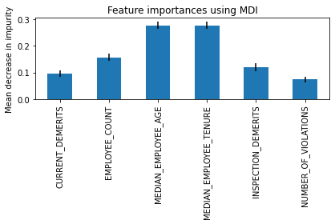

```python
# create feature importance plot

forest_importances = pd.Series(importances, index=feature_names)

fig, ax = plt.subplots()
forest_importances.plot.bar(yerr=std, ax=ax)
ax.set_title("Feature importances using MDI")
ax.set_ylabel("Mean decrease in impurity")
fig.tight_layout()
```

### We can see that looking only at the top three most important features, these are 'MEDIAN_EMPLOYEE_AGE', 'MEDIAN_EMPLOYEE_TENURE', and 'EMPLOYEE_COUNT'. Let's now consider all features and see what the results are.

```python
# retrieve all features now, including ones that were engineered
X_num = pd.concat([X_num_only, explore.iloc[:, [i for i in range(8, 16)]]], axis=1, join="inner")
# retrieve copy of response variable as well
y_num = explore['NEXT_INSPECTION_GRADE_C_OR_BELOW'].copy()
```

```python
# check to see that all columns are numeric data types
X_num.info()
```

```
<class 'pandas.core.frame.DataFrame'>
Int64Index: 12501 entries, 6593 to 7290
Data columns (total 14 columns):
 #   Column                  Non-Null Count  Dtype
---  ------                  --------------  -----
 0   CURRENT_DEMERITS        12501 non-null  float64
 1   EMPLOYEE_COUNT          12501 non-null  float64
 2   MEDIAN_EMPLOYEE_AGE     12501 non-null  float64
 3   MEDIAN_EMPLOYEE_TENURE  12501 non-null  float64
 4   INSPECTION_DEMERITS     12501 non-null  float64
 5   NUMBER_OF_VIOLATIONS    12501 non-null  float64
 6   CURRENT_GRADE_C         12501 non-null  int64
 7   CURRENT_GRADE_X         12501 non-null  int64
 8   CURRENT_GRADE_OTHER     12501 non-null  int64
 9   RE-INSPEC               12501 non-null  int64
 10  OTHER-INSPEC            12501 non-null  int64
 11  CRITICAL_COUNT          12501 non-null  int64
 12  MAJOR_COUNT             12501 non-null  int64
 13  NON-MAJOR_COUNT         12501 non-null  int64
dtypes: float64(6), int64(8)
memory usage: 1.7 MB
```

```python
# create list of feature names for our numerical features
all_cols = list(X_num.columns)
feature_names = [f"{all_cols[i]}" for i in range(X_num.shape[1])]
# create forest model
forest_num = RandomForestClassifier(random_state=0)
# fit model
forest_num.fit(X_num, y_num)
```

```
RandomForestClassifier(random_state=0)
```

```python
start_time = time.time()
# store feature importances
importances = forest_num.feature_importances_
# store mean difference in impurity
std = np.std([tree.feature_importances_ for tree in forest_num.estimators_], axis=0)
elapsed_time = time.time() - start_time

print(f"Elapsed time to compute the importances: {elapsed_time:.3f} seconds")
```

```
Elapsed time to compute the importances: 0.033 seconds
```

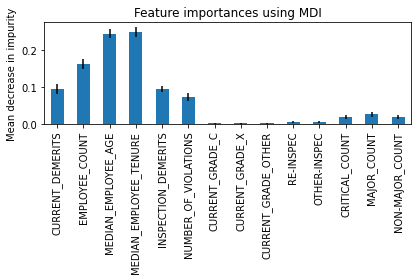

```python
# create feature importance plot

forest_importances = pd.Series(importances, index=feature_names)

fig, ax = plt.subplots()
forest_importances.plot.bar(yerr=std, ax=ax)
ax.set_title("Feature importances using MDI")
ax.set_ylabel("Mean decrease in impurity")
fig.tight_layout()
```

### When we include all features, we get similar results. The top 5 most important features are 'MEDIAN_EMPLOYEE_AGE', 'MEDIAN_EMPLOYEE_TENURE', 'EMPLOYEE_COUNT', 'CURRENT_DEMERITS', and 'INSPECTION_DEMERITS'.

### Now let's perform feature importance based on feature permutation. This is essentially a way of measuring how much our model depends on a particular feature to make its final predictions.

```python
from sklearn.inspection import permutation_importance

start_time = time.time()
# store results of permutation importance
result = permutation_importance(
    forest_num, X_num, y_num, n_repeats=10, random_state=42, n_jobs=-1
)
elapsed_time = time.time() - start_time
print(f"Elapsed time to compute the importances: {elapsed_time:.3f} seconds")

# final feature importances are stored
forest_importances = pd.Series(result.importances_mean, index=feature_names)
```

```
Elapsed time to compute the importances: 20.762 seconds
```

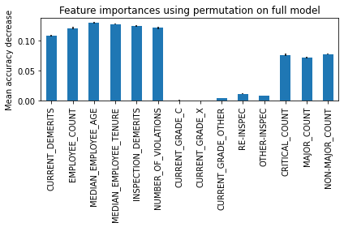

```python
# plot resultant feature importances based on feature permutation
fig, ax = plt.subplots()
forest_importances.plot.bar(yerr=result.importances_std, ax=ax)
ax.set_title("Feature importances using permutation on full model")
ax.set_ylabel("Mean accuracy decrease")
fig.tight_layout()
plt.show()
```

### We can see that based on feature permutation, the features 'MEDIAN_EMPLOYEE_AGE', 'MEDIAN_EMPLOYEE_TENURE', 'EMPLOYEE_COUNT', 'CURRENT_DEMERITS', 'INSPECTION_DEMERITS', 'NUMBER_OF_VIOLATIONS', 'CRITICAL_COUNT', 'MAJOR_COUNT', and 'NON-MAJOR_COUNT' are relatively important to our model's final predictions. Thus, these are the features we will include in our final model.

```python
X_num = X_num[['MEDIAN_EMPLOYEE_AGE', 'MEDIAN_EMPLOYEE_TENURE', 'EMPLOYEE_COUNT',
               'CURRENT_DEMERITS', 'INSPECTION_DEMERITS', 'NUMBER_OF_VIOLATIONS',
               'CRITICAL_COUNT', 'MAJOR_COUNT', 'NON-MAJOR_COUNT']].copy()
```

### Before testing our final model on our validation set, we will see how it performs on the training set using cross-validation.

```python
from sklearn.model_selection import cross_val_score

# create RandomForestClassifier model
final_model = RandomForestClassifier(random_state = 42)


# store results of CV scores
results = cross_val_score(final_model, X_num, y_num, scoring = 'accuracy', cv = 5, n_jobs = -1)

print(results)
print('The average CV score with 5 folds is {}'.format(np.mean(results)))
```

```
[0.83046781 0.8256     0.8292     0.8284     0.8288    ]
The average CV score with 5 folds is 0.82849356257497
```

```python
# store precision results
precision = cross_val_score(final_model, X_num, pd.to_numeric(y_num), scoring='precision',
                         cv=5, n_jobs = -1)

# store recall results
recall = cross_val_score(final_model, X_num, pd.to_numeric(y_num), scoring='recall',
                         cv=5, n_jobs = -1)
# store f1_score results
f1_score = cross_val_score(final_model, X_num, pd.to_numeric(y_num), scoring='f1',
                         cv=5, n_jobs = -1)

print('Our average precision score is {}, our average recall score is {}, and our average f1 score is {}'.format\
     (np.mean(precision), np.mean(recall), np.mean(f1_score)))
```

```
Our average precision score is 0.28345765345765345, our average recall score is 0.008520721992538066, and our average f1 score is 0.01651058185333959
```

### Unfortunately, our average recall, precision, and f1 score is very low. This is highly due to the fact that we have an unbalanced dataset, whereby there are many more locations that don't score a grade C or below than those that do. Thus, we must somehow account for this.

### First, we will use the library imblearn. imblearn was created to deal with unbalanced datasets for machine learning problems, and works seamlessly with sci-kit learn. Thus, we start off with imblearn's BalancedRandomForestClassifier model with default parameters. BalancedRandomForestClassifier works by undersampling the majority class for each boostrapping iteration, so that the majority and minority classes have equal weight. This is more effective than simply undersampling our dataset from the onset and we are able to preserve the information that comes in all our data.

```python
from imblearn.ensemble import BalancedRandomForestClassifier

# create BalancedRandomForestClassifier model
model = BalancedRandomForestClassifier()

precision = cross_val_score(test, X_num, pd.to_numeric(y_num), scoring='precision',
                         cv=5, n_jobs = -1)

recall = cross_val_score(test, X_num, pd.to_numeric(y_num), scoring='recall',
                         cv=5, n_jobs = -1)

f1_score = cross_val_score(test, X_num, pd.to_numeric(y_num), scoring='f1',
                         cv=5, n_jobs = -1)

print('Our average precision score is {}, our average recall score is {}, and our average f1 score is {}'.format\
     (np.mean(precision), np.mean(recall), np.mean(f1_score)))
```

```
Our average precision score is 0.18178215864080538, our average recall score is 0.2514077958163871, and our average f1 score is 0.2108834313465377
```

### We will accomplish this by performing a grid search on our hyper-parameter space.

```python
from sklearn.model_selection import GridSearchCV

# establish hyper-parameter space to search from
params = {'n_estimators':[50, 100, 300, 500],
         'max_depth': [3, 4, 7], 'max_features': ['sqrt', 5, 7, 8]}

# create new BalancedRandomForestClassifier model
new_model = BalancedRandomForestClassifier(random_state = 42)

# create grid with hyper-parameter space
grid_search = GridSearchCV(new_model, params, scoring = 'f1', n_jobs = -1)

grid_search.fit(X_num, pd.to_numeric(y_num))

cv = grid_search.cv_results_

for scores, params in sorted(zip(cv['mean_test_score'], cv['params']), reverse = True):
                             print(scores, params)
```

```
0.2654886839388137 {'max_depth': 7, 'max_features': 7, 'n_estimators': 300}
0.2635259137779037 {'max_depth': 7, 'max_features': 5, 'n_estimators': 300}
0.26321765377182466 {'max_depth': 7, 'max_features': 7, 'n_estimators': 50}
0.26140487417037583 {'max_depth': 7, 'max_features': 'sqrt', 'n_estimators': 300}
0.2609536316806086 {'max_depth': 7, 'max_features': 5, 'n_estimators': 100}
0.26074656800938234 {'max_depth': 4, 'max_features': 'sqrt', 'n_estimators': 50}
0.2606525908741274 {'max_depth': 7, 'max_features': 7, 'n_estimators': 100}
0.2605047891851094 {'max_depth': 3, 'max_features': 7, 'n_estimators': 300}
0.2598363819050735 {'max_depth': 3, 'max_features': 8, 'n_estimators': 300}
0.25949012296304513 {'max_depth': 7, 'max_features': 8, 'n_estimators': 100}
0.2593053941413189 {'max_depth': 4, 'max_features': 8, 'n_estimators': 300}
0.25914204190740814 {'max_depth': 7, 'max_features': 5, 'n_estimators': 50}
0.2588660143900282 {'max_depth': 3, 'max_features': 'sqrt', 'n_estimators': 300}
0.25880019574986374 {'max_depth': 4, 'max_features': 7, 'n_estimators': 300}
0.2587638317275302 {'max_depth': 7, 'max_features': 8, 'n_estimators': 300}
0.2585245643043323 {'max_depth': 7, 'max_features': 8, 'n_estimators': 50}
0.2583464869484272 {'max_depth': 4, 'max_features': 7, 'n_estimators': 100}
0.2580537552659147 {'max_depth': 3, 'max_features': 8, 'n_estimators': 100}
0.2576123436365014 {'max_depth': 4, 'max_features': 'sqrt', 'n_estimators': 100}
0.2572012295395758 {'max_depth': 4, 'max_features': 8, 'n_estimators': 50}
0.2570753688971657 {'max_depth': 4, 'max_features': 8, 'n_estimators': 100}
0.2563958504381338 {'max_depth': 3, 'max_features': 5, 'n_estimators': 50}
0.25615957815400325 {'max_depth': 4, 'max_features': 'sqrt', 'n_estimators': 300}
0.25559138617329924 {'max_depth': 3, 'max_features': 5, 'n_estimators': 100}
0.25533565476686226 {'max_depth': 4, 'max_features': 5, 'n_estimators': 50}
0.25488910217989125 {'max_depth': 4, 'max_features': 7, 'n_estimators': 50}
0.25470509578529427 {'max_depth': 3, 'max_features': 7, 'n_estimators': 50}
0.2546848551212987 {'max_depth': 3, 'max_features': 5, 'n_estimators': 300}
0.25449574802085484 {'max_depth': 3, 'max_features': 'sqrt', 'n_estimators': 100}
0.2542469427403905 {'max_depth': 4, 'max_features': 5, 'n_estimators': 100}
0.25385305837507294 {'max_depth': 4, 'max_features': 5, 'n_estimators': 300}
0.25371361915244756 {'max_depth': 7, 'max_features': 'sqrt', 'n_estimators': 50}
0.25230146677840826 {'max_depth': 3, 'max_features': 7, 'n_estimators': 100}
0.2521394008621295 {'max_depth': 3, 'max_features': 8, 'n_estimators': 50}
0.2520966419978974 {'max_depth': 3, 'max_features': 'sqrt', 'n_estimators': 50}
0.25178834009383855 {'max_depth': 7, 'max_features': 'sqrt', 'n_estimators': 100}
```

### We can see that the model with the best performance has hyper-parameters 'max_depth': 7, 'max_features': 7, 'n_estimators': 300. Thus, our final model will have these same hyper-parameters.

### We will now train our model on the entire training set and test its performance on the validation set.

```python
validation_model = BalancedRandomForestClassifier(max_depth = 7, max_features = 7, n_estimators = 300)
# fit model on training data
validation_model.fit(X_num, y_num)
```

```
BalancedRandomForestClassifier(max_depth=7, max_features=7, n_estimators=300)
```

### Now we must perform all the processing we did on training data to validation data

### Extract relevant features/features model was trained on

```python
X_test_processed = X_test[['MEDIAN_EMPLOYEE_AGE', 'MEDIAN_EMPLOYEE_TENURE', 'EMPLOYEE_COUNT',
                            'CURRENT_DEMERITS', 'INSPECTION_DEMERITS', 'NUMBER_OF_VIOLATIONS',
                           'FIRST_VIOLATION_TYPE','SECOND_VIOLATION_TYPE','THIRD_VIOLATION_TYPE']].copy()
```

### Perform relevant feature processing/engineering

```python
# first create columns that return 1 if violation is type 'critical', 0 otherwise
X_test_processed['first_critical'] = X_test_processed['FIRST_VIOLATION_TYPE'].apply(lambda x: 1 if x == 'Critical' else 0)
X_test_processed['second_critical'] = X_test_processed['SECOND_VIOLATION_TYPE'].apply(lambda x: 1 if x == 'Critical' else 0)
X_test_processed['third_critical'] = X_test_processed['THIRD_VIOLATION_TYPE'].apply(lambda x: 1 if x == 'Critical' else 0)
```

```python
# then create a column that returns the count of type 'critical' by summing along our previously created columns
X_test_processed['CRITICAL_COUNT'] = X_test_processed[['first_critical', 'second_critical', 'third_critical']].sum(axis = 1)
```

```python
# first create columns that return 1 if violation is type 'major', 0 otherwise
X_test_processed['first_major'] = X_test_processed['FIRST_VIOLATION_TYPE'].apply(lambda x: 1 if x == 'Major' else 0)
X_test_processed['second_major'] = X_test_processed['SECOND_VIOLATION_TYPE'].apply(lambda x: 1 if x == 'Major' else 0)
X_test_processed['third_major'] = X_test_processed['THIRD_VIOLATION_TYPE'].apply(lambda x: 1 if x == 'Major' else 0)
```

```python
# then create a column that returns the count of type 'major' by summing along our previously created columns
X_test_processed['MAJOR_COUNT'] = X_test_processed[['first_major', 'second_major', 'third_major']].sum(axis = 1)
```

```python
# first create columns that return 1 if violation is type 'non-major', 0 otherwise
X_test_processed['first_non-major'] = X_test_processed['FIRST_VIOLATION_TYPE'].apply(lambda x: 1 if x == 'Non-Major' else 0)
X_test_processed['second_non-major'] = X_test_processed['SECOND_VIOLATION_TYPE'].apply(lambda x: 1 if x == 'Non-Major' else 0)
X_test_processed['third_non-major'] = X_test_processed['THIRD_VIOLATION_TYPE'].apply(lambda x: 1 if x == 'Non-Major' else 0)
```

```python
# then create a column that returns the count of type 'non-major' by summing along our previously created columns
X_test_processed['NON-MAJOR_COUNT'] = X_test_processed[['first_non-major', 'second_non-major', 'third_non-major']].sum(axis = 1)
```

### Drop features we no longer need after feature processing/engineering

```python
# then drop the binary-valued columns since we no longer need them anymore
X_test_processed.drop(['first_non-major','second_non-major','third_non-major',
             'first_major','second_major','third_major',
             'first_critical', 'second_critical', 'third_critical'], axis = 1, inplace = True)
```

```python
X_test_processed.drop(['FIRST_VIOLATION_TYPE', 'SECOND_VIOLATION_TYPE', 'THIRD_VIOLATION_TYPE'], axis = 1, inplace = True)
```

```python
X_test_processed.info()
```

```
<class 'pandas.core.frame.DataFrame'>
Int64Index: 3126 entries, 513 to 14329
Data columns (total 9 columns):
 #   Column                  Non-Null Count  Dtype
---  ------                  --------------  -----
 0   MEDIAN_EMPLOYEE_AGE     3120 non-null   object
 1   MEDIAN_EMPLOYEE_TENURE  3072 non-null   float64
 2   EMPLOYEE_COUNT          3115 non-null   float64
 3   CURRENT_DEMERITS        3079 non-null   float64
 4   INSPECTION_DEMERITS     3081 non-null   object
 5   NUMBER_OF_VIOLATIONS    3083 non-null   object
 6   CRITICAL_COUNT          3126 non-null   int64
 7   MAJOR_COUNT             3126 non-null   int64
 8   NON-MAJOR_COUNT         3126 non-null   int64
dtypes: float64(3), int64(3), object(3)
memory usage: 244.2+ KB
```

### Convert 'object' data-types to numeric types

```python
obj_cols = ['MEDIAN_EMPLOYEE_AGE', 'INSPECTION_DEMERITS', 'NUMBER_OF_VIOLATIONS'
           ]
# convert each feature to numeric types. The argument errors = 'coerce' forces non-numerics into NaNs
X_test_processed[obj_cols] = X_test_processed[obj_cols].apply(pd.to_numeric, errors='coerce')
```

### Now perform permuting process

```python
# columns we want to impute on
cols = ['CURRENT_DEMERITS', 'EMPLOYEE_COUNT', 'MEDIAN_EMPLOYEE_AGE',
        'MEDIAN_EMPLOYEE_TENURE', 'INSPECTION_DEMERITS', 'NUMBER_OF_VIOLATIONS']
# impute using the mode of each column
X_test_processed[cols]=X_test_processed[cols].fillna(X_test_processed.mode().iloc[0])
```

### Now convert 'object' types back to numeric types

```python
# convert 'object' types to 'float64' types
X_test_processed[obj_cols] = X_test_processed[obj_cols].apply(pd.to_numeric)
```

### Sanity check

```python
X_test_processed.info()
```

```
<class 'pandas.core.frame.DataFrame'>
Int64Index: 3126 entries, 513 to 14329
Data columns (total 9 columns):
 #   Column                  Non-Null Count  Dtype
---  ------                  --------------  -----
 0   MEDIAN_EMPLOYEE_AGE     3126 non-null   float64
 1   MEDIAN_EMPLOYEE_TENURE  3126 non-null   float64
 2   EMPLOYEE_COUNT          3126 non-null   float64
 3   CURRENT_DEMERITS        3126 non-null   float64
 4   INSPECTION_DEMERITS     3126 non-null   float64
 5   NUMBER_OF_VIOLATIONS    3126 non-null   float64
 6   CRITICAL_COUNT          3126 non-null   int64
 7   MAJOR_COUNT             3126 non-null   int64
 8   NON-MAJOR_COUNT         3126 non-null   int64
dtypes: float64(6), int64(3)
memory usage: 244.2 KB
```

```python
# Now assess model performance on validation set using a classification report
```

```python
from sklearn.metrics import classification_report
y_true = y_test.copy()
predictions = validation_model.predict(X_test_processed)
print(classification_report(y_true, predictions))
```

```
              precision    recall  f1-score   support

           0       0.84      0.66      0.74      2558
           1       0.23      0.45      0.30       568

    accuracy                           0.62      3126
   macro avg       0.54      0.56      0.52      3126
weighted avg       0.73      0.62      0.66      3126
```

### Now let's perform this process for our test set

### Read in test set

```python
test_data = pd.read_csv('Data/TEST_SET_2022.csv')
```

### Extract relevant features/features model was trained on

```python
test_processed = test_data[['MEDIAN_EMPLOYEE_AGE', 'MEDIAN_EMPLOYEE_TENURE', 'EMPLOYEE_COUNT',
                            'CURRENT_DEMERITS', 'INSPECTION_DEMERITS', 'NUMBER_OF_VIOLATIONS',
                           'FIRST_VIOLATION_TYPE','SECOND_VIOLATION_TYPE','THIRD_VIOLATION_TYPE']].copy()
```

### Perform relevant feature processing/engineering

```python
# first create columns that return 1 if violation is type 'critical', 0 otherwise
test_processed['first_critical'] = test_processed['FIRST_VIOLATION_TYPE'].apply(lambda x: 1 if x == 'Critical' else 0)
test_processed['second_critical'] = test_processed['SECOND_VIOLATION_TYPE'].apply(lambda x: 1 if x == 'Critical' else 0)
test_processed['third_critical'] = test_processed['THIRD_VIOLATION_TYPE'].apply(lambda x: 1 if x == 'Critical' else 0)
```

```python
# then create a column that returns the count of type 'critical' by summing along our previously created columns
test_processed['CRITICAL_COUNT'] = test_processed[['first_critical', 'second_critical', 'third_critical']].sum(axis = 1)
```

```python
# first create columns that return 1 if violation is type 'major', 0 otherwise
test_processed['first_major'] = test_processed['FIRST_VIOLATION_TYPE'].apply(lambda x: 1 if x == 'Major' else 0)
test_processed['second_major'] = test_processed['SECOND_VIOLATION_TYPE'].apply(lambda x: 1 if x == 'Major' else 0)
test_processed['third_major'] = test_processed['THIRD_VIOLATION_TYPE'].apply(lambda x: 1 if x == 'Major' else 0)
```

```python
# then create a column that returns the count of type 'major' by summing along our previously created columns
test_processed['MAJOR_COUNT'] = test_processed[['first_major', 'second_major', 'third_major']].sum(axis = 1)
```

```python
# first create columns that return 1 if violation is type 'non-major', 0 otherwise
test_processed['first_non-major'] = test_processed['FIRST_VIOLATION_TYPE'].apply(lambda x: 1 if x == 'Non-Major' else 0)
test_processed['second_non-major'] = test_processed['SECOND_VIOLATION_TYPE'].apply(lambda x: 1 if x == 'Non-Major' else 0)
test_processed['third_non-major'] = test_processed['THIRD_VIOLATION_TYPE'].apply(lambda x: 1 if x == 'Non-Major' else 0)
```

```python
# then create a column that returns the count of type 'non-major' by summing along our previously created columns
test_processed['NON-MAJOR_COUNT'] = test_processed[['first_non-major', 'second_non-major', 'third_non-major']].sum(axis = 1)
```

### Drop features we no longer need after feature processing/engineering

```python
# then drop the binary-valued columns since we no longer need them anymore
test_processed.drop(['first_non-major','second_non-major','third_non-major',
             'first_major','second_major','third_major',
             'first_critical', 'second_critical', 'third_critical'], axis = 1, inplace = True)
```

```python
test_processed.drop(['FIRST_VIOLATION_TYPE', 'SECOND_VIOLATION_TYPE', 'THIRD_VIOLATION_TYPE'], axis = 1, inplace = True)
```

```python
test_processed.info()
```

```
<class 'pandas.core.frame.DataFrame'>
RangeIndex: 7505 entries, 0 to 7504
Data columns (total 9 columns):
 #   Column                  Non-Null Count  Dtype
---  ------                  --------------  -----
 0   MEDIAN_EMPLOYEE_AGE     7505 non-null   float64
 1   MEDIAN_EMPLOYEE_TENURE  7505 non-null   float64
 2   EMPLOYEE_COUNT          7505 non-null   float64
 3   CURRENT_DEMERITS        7505 non-null   int64
 4   INSPECTION_DEMERITS     7505 non-null   int64
 5   NUMBER_OF_VIOLATIONS    7505 non-null   int64
 6   CRITICAL_COUNT          7505 non-null   int64
 7   MAJOR_COUNT             7505 non-null   int64
 8   NON-MAJOR_COUNT         7505 non-null   int64
dtypes: float64(3), int64(6)
memory usage: 527.8 KB
```

### Convert 'object' data-types to numeric types

```python
obj_cols = ['MEDIAN_EMPLOYEE_AGE', 'INSPECTION_DEMERITS', 'NUMBER_OF_VIOLATIONS'
           ]
# convert each feature to numeric types. The argument errors = 'coerce' forces non-numerics into NaNs
test_processed[obj_cols] = test_processed[obj_cols].apply(pd.to_numeric, errors='coerce')
```

### Now perform permuting process

```python
# columns we want to impute on
cols = ['CURRENT_DEMERITS', 'EMPLOYEE_COUNT', 'MEDIAN_EMPLOYEE_AGE',
        'MEDIAN_EMPLOYEE_TENURE', 'INSPECTION_DEMERITS', 'NUMBER_OF_VIOLATIONS']
# impute using the mode of each column
test_processed[cols]=test_processed[cols].fillna(test_processed.mode().iloc[0])
```

### Now convert 'object' types back to numeric types

```python
# convert 'object' types to 'float64' types
test_processed[obj_cols] = test_processed[obj_cols].apply(pd.to_numeric)
```

### Sanity check

```python
test_processed.info()
```

[output not shown]

### Lastly, train model on full training data and assess performance on testing data

```python
training_data = pd.concat([X_num, X_test_processed])
training_y = pd.concat([y_num, y_test])
```

```python
final_model = BalancedRandomForestClassifier(max_depth = 7, max_features = 7, n_estimators = 300)
final_model.fit(training_data, training_y)
```

```
BalancedRandomForestClassifier(max_depth=7, max_features=7, n_estimators=300)
```

```python
probs = final_model.predict_proba(test_processed)
```

```python
# get column that contains probabilities of scoring grade C or below
prob_of_c_below = probs[:, 1]
```

```python
final_csv = pd.DataFrame()
final_csv['RESTAURANT_SERIAL_NUMBER'] = test_data['RESTAURANT_SERIAL_NUMBER']
final_csv['CLASSIFIER_PROBABILITY'] = pd.Series(prob_of_c_below)
final_csv['CLASSIFIER_PREDICTION'] = final_csv['CLASSIFIER_PROBABILITY'].apply(lambda x: 1 if x >  0.5 else 0)
```

```python
final_csv.to_csv('predictions_Serrata_Brian.csv')
```